# Cover-weighted trait models

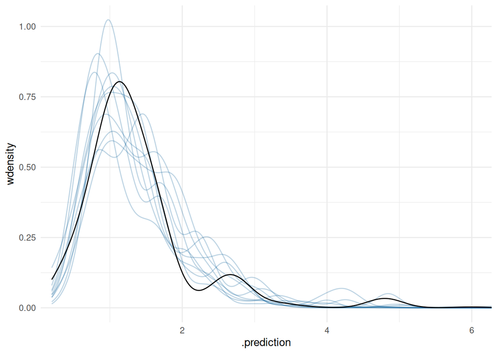

```r
my_ppc(fit_ph_itp, cwm_ITP$data$ph)
```

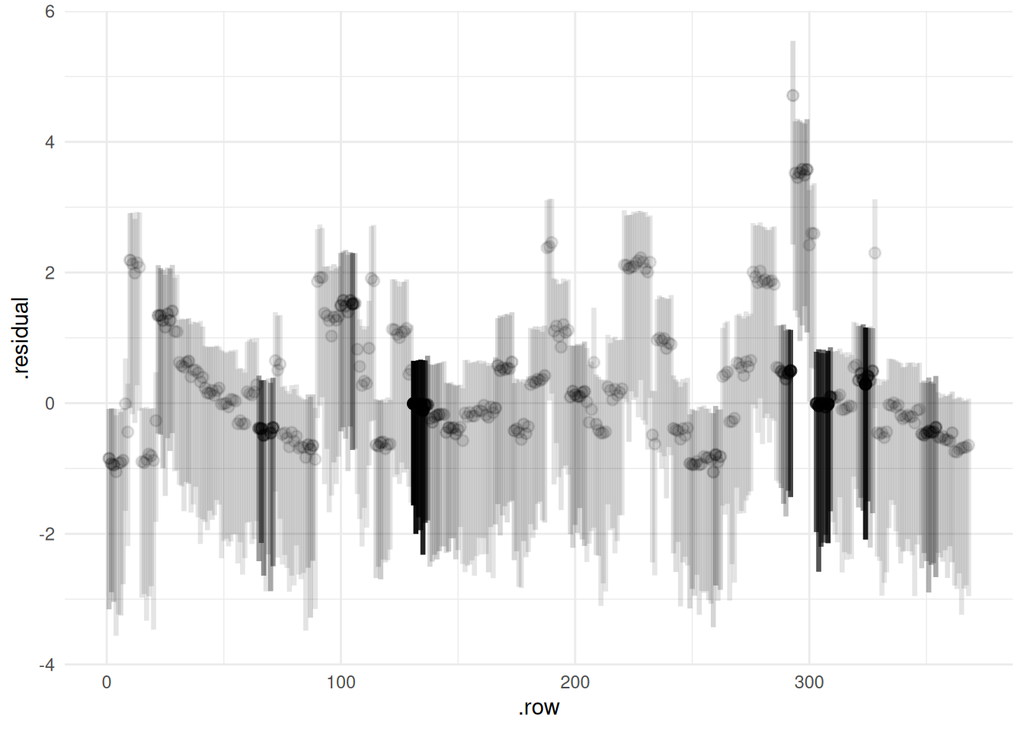

```r
my_resplot(fit_ph_itp, cwm_ITP$data$ph[[1]])
```

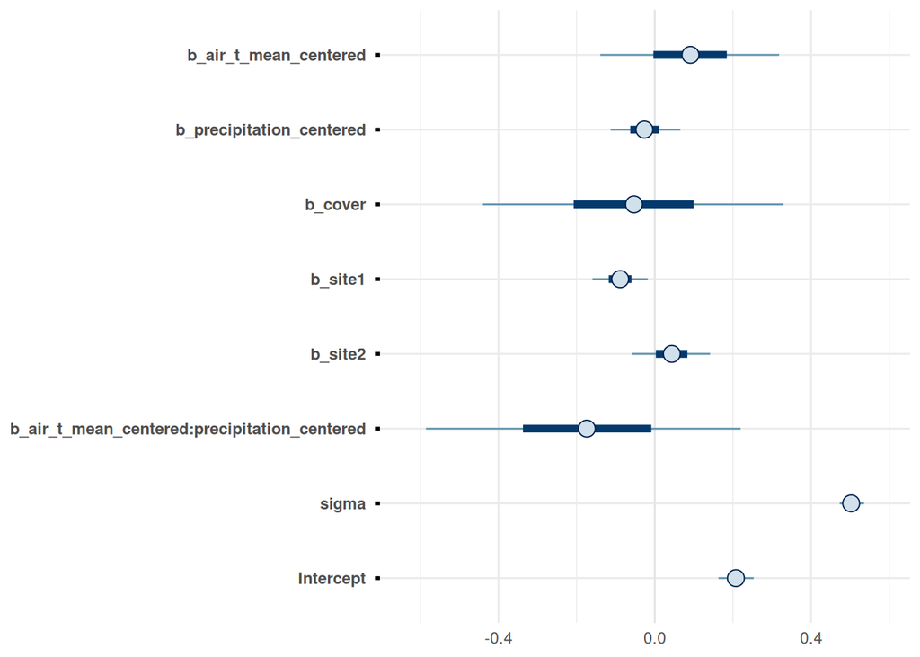

```r
mcmc_intervals(fit_ph_itp, pars = show)
```

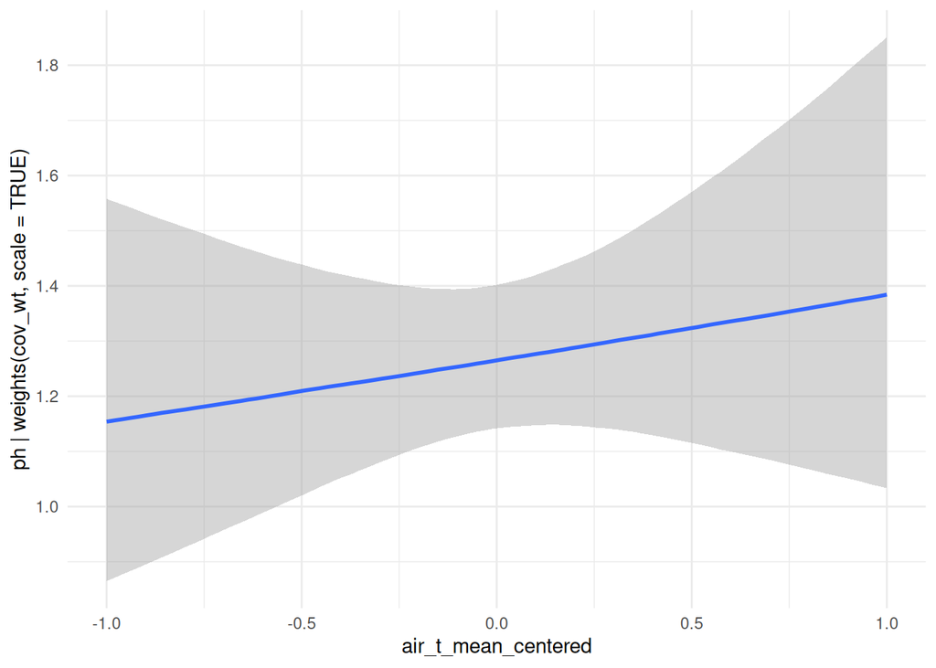

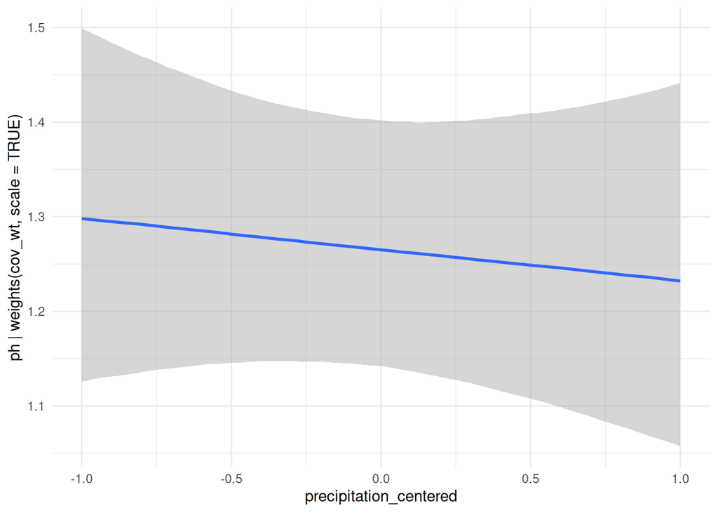

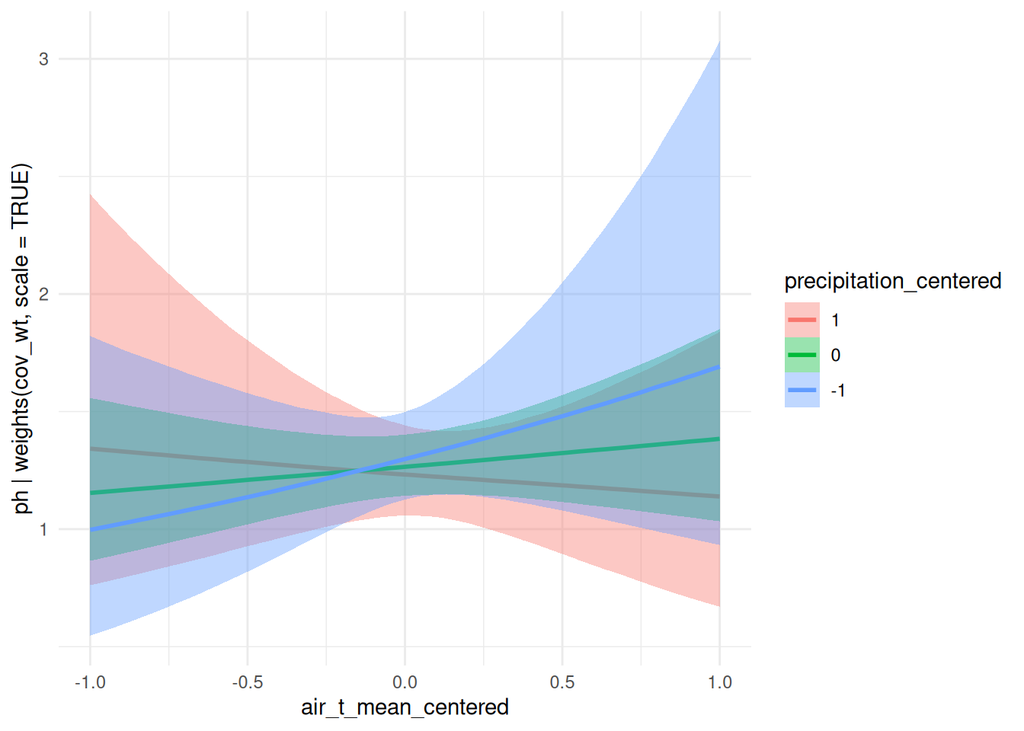

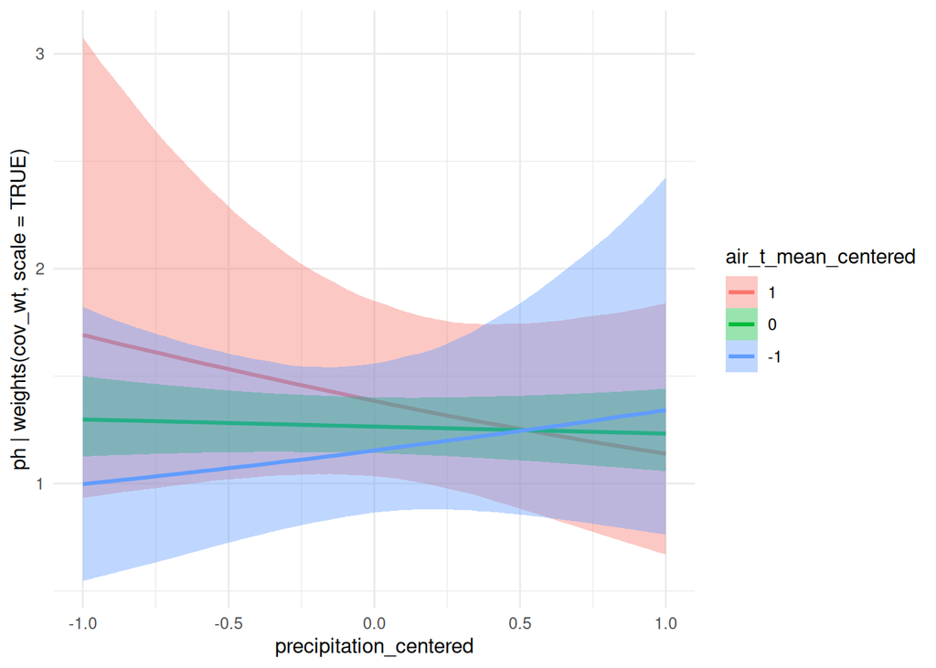

```r
my_ceffects(fit_ph_itp)
```

## 5.4 Specific leaf area

```r
fit_sla_itp <- brm_multiple(sla | weights(cov_wt, scale = TRUE) ~
                              air_t_mean_centered + precipitation_centered +
                              air_t_mean_centered:precipitation_centered + cover + site,
                            data = cwm_ITP$data$sla,
                            prior = prior_ln(cwm_ITP$data$sla[[1]]$sla),
                            family = "lognormal",
                            file = "fits/cwm/sla.itp",
                            file_refit = "never",
                            control = list(seed = 2853))

prior_summary(fit_sla_itp)
```

| prior | class | coef | group | resp | dpar | nlpar | lb | ub | tag | source |
| --- | --- | --- | --- | --- | --- | --- | --- | --- | --- | --- |
| student_t(5, 0, 0.5) | b |  |  |  |  |  |  |  |  | user |
|  | b | air_t_mean_centered |  |  |  |  |  |  |  | default |
|  | b | air_t_mean_centered:precipitation_centered |  |  |  |  |  |  |  | default |
|  | b | cover |  |  |  |  |  |  |  | default |
|  | b | precipitation_centered |  |  |  |  |  |  |  | default |
|  | b | site1 |  |  |  |  |  |  |  | default |
|  | b | site2 |  |  |  |  |  |  |  | default |
| student_t(3, 0.694, 0.6) | Intercept |  |  |  |  |  |  |  |  | user |
| student_t(5, 0, 0.5) | sigma |  |  |  |  |  | 0 |  |  | user |

```r
fit_sla_itp
```

```
 Family: lognormal
  Links: mu = identity
Formula: sla | weights(cov_wt, scale = TRUE) ~ air_t_mean_centered + precipitation_centered + air_t_mean_centered:precipitation_centered + cover + site
   Data: cwm_ITP$data$sla (Number of observations: 368)
  Draws: 20 chains, each with iter = 2000; warmup = 1000; thin = 1;
         total post-warmup draws = 20000

Regression Coefficients:
                                           Estimate Est.Error l-95% CI u-95% CI
Intercept                                      1.31      0.78    -0.22     2.87
air_t_mean_centered                           -0.03      0.12    -0.27     0.20
precipitation_centered                         0.01      0.04    -0.07     0.09
cover                                         -0.24      0.22    -0.68     0.18
site1                                          0.18      0.04     0.11     0.26
site2                                         -0.61      0.05    -0.72    -0.50
air_t_mean_centered:precipitation_centered     0.20      0.21    -0.22     0.61

Further Distributional Parameters:
      Estimate Est.Error l-95% CI u-95% CI
sigma     0.42      0.02     0.40     0.46

Draws were sampled using sample(hmc). Overall Rhat and ESS estimates
are not informative for brm_multiple models and are hence not displayed.
Please see ?brm_multiple for how to assess convergence of such models.
```

```r
multiple_convergence(fit_sla_itp)
```

| variable | rhat | ess_bulk | ess_tail |
| --- | --- | --- | --- |
| b_Intercept | 1 | 2053 | 2484 |
| b_air_t_mean_centered | 1 | 3477 | 2780 |
| b_precipitation_centered | 1 | 2736 | 2520 |
| b_cover | 1 | 2048 | 2516 |
| b_site1 | 1 | 2354 | 2694 |
| b_site2 | 1 | 1839 | 2108 |
| b_air_t_mean_centered:precipitation_centered | 1 | 2811 | 2387 |
| sigma | 1 | 3578 | 2897 |
| Intercept | 1 | 3546 | 2863 |

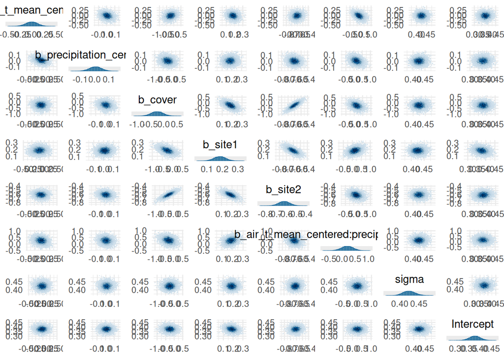

```r
my_mcmc_pairs(fit_sla_itp)
```

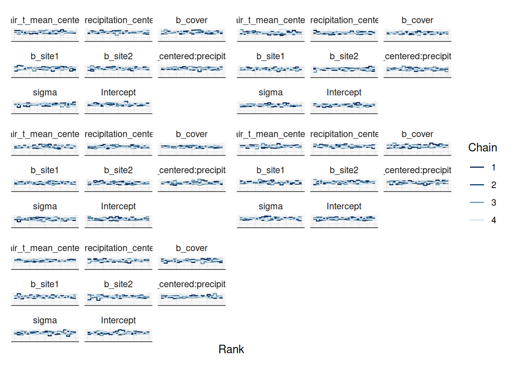

```r
trank(fit_sla_itp)
```

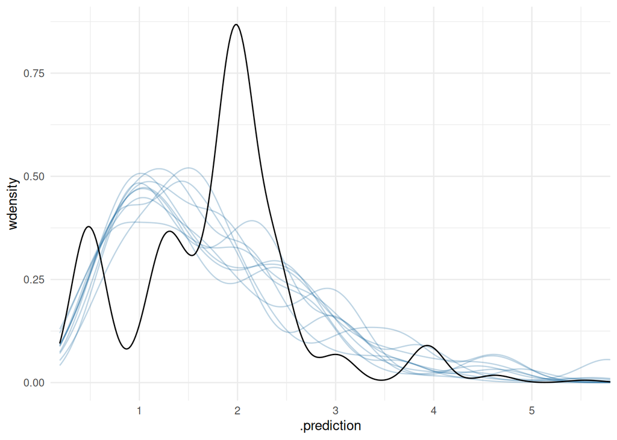

```r
my_ppc(fit_sla_itp, cwm_ITP$data$sla)
```

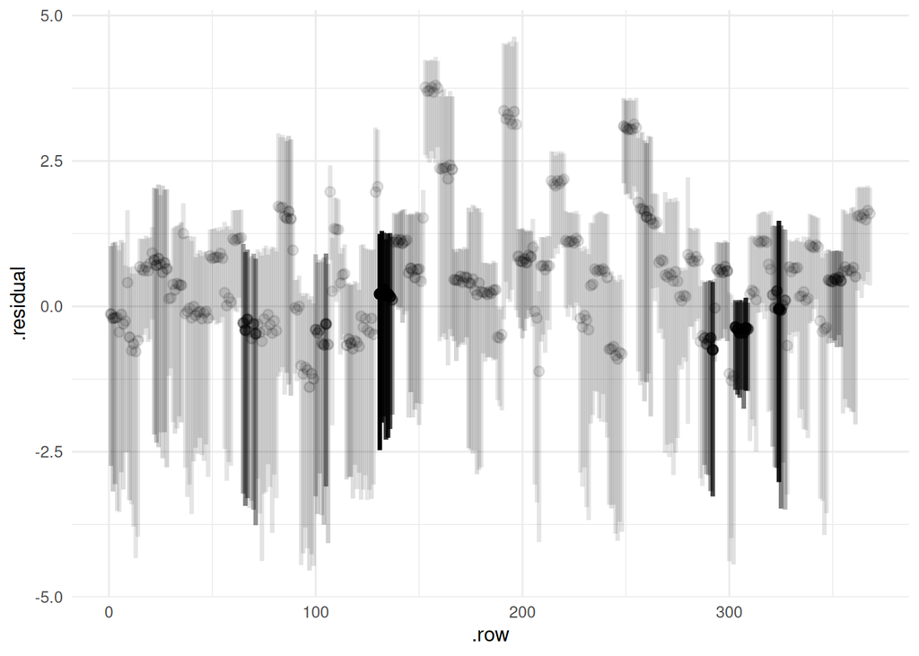

```r
my_resplot(fit_sla_itp, cwm_ITP$data$sla[[1]])
```

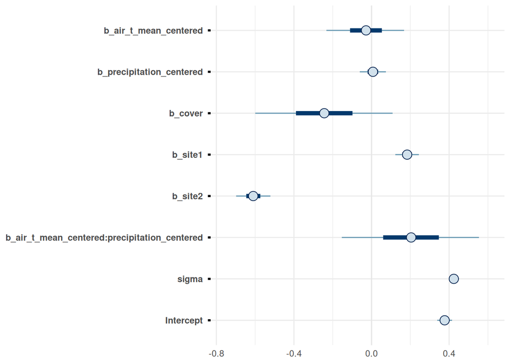

```r
mcmc_intervals(fit_sla_itp, pars = show)
```

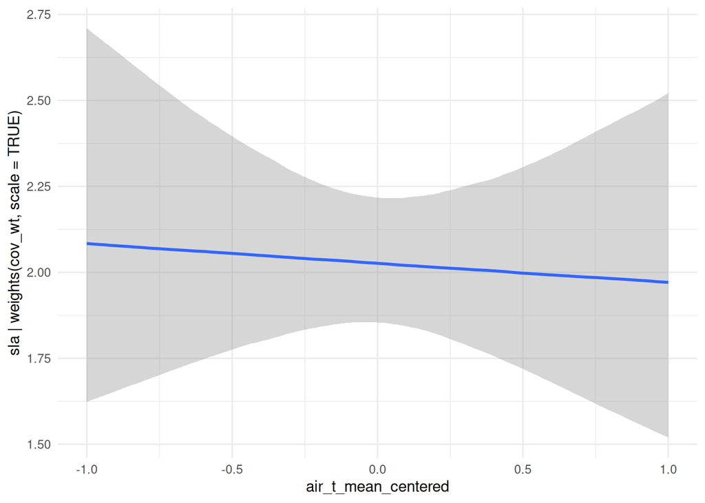

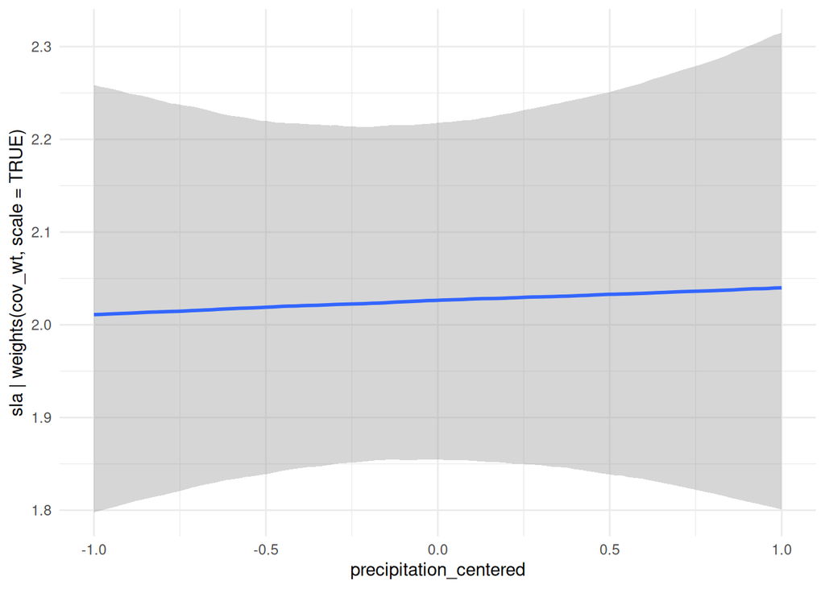

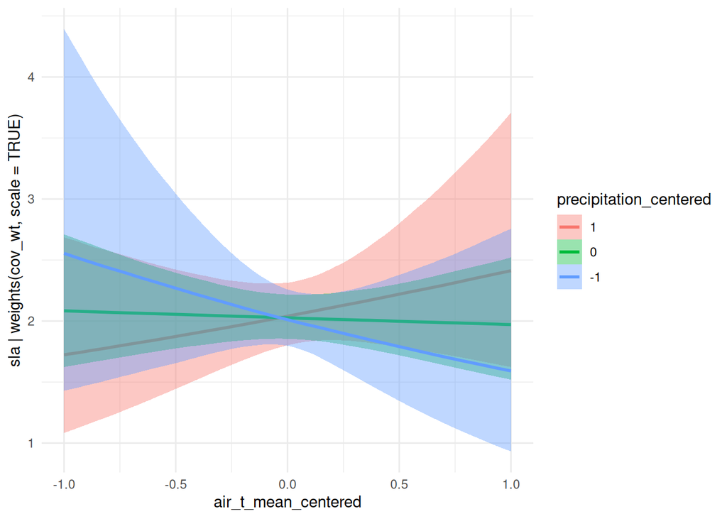

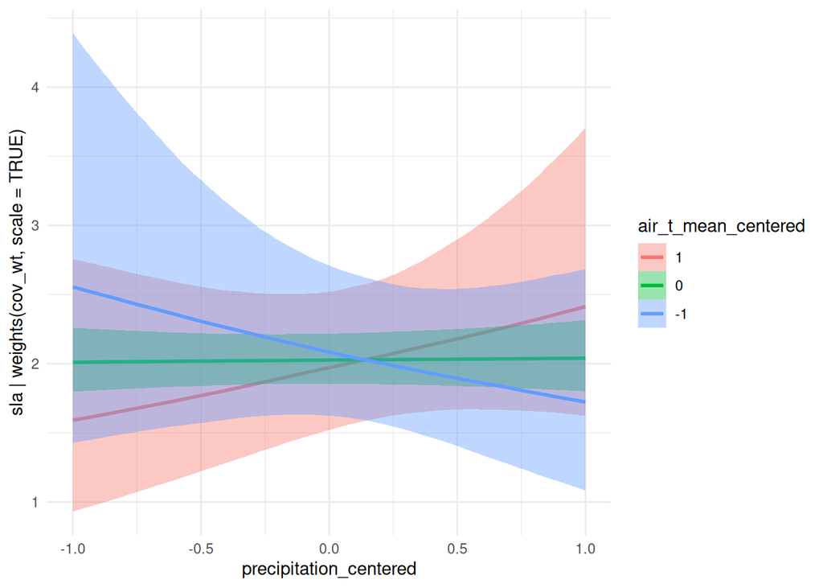

```r
my_ceffects(fit_sla_itp)
```

## 5.5 Stem-specific density

*Ilex aquifolium* and *Ruscus aculeatus* have clearly higher SSD than the rest. While they are woody shrubs, there are other shrubs and woody species with lower values, so this doesn’t fully account for the differences.

```r
fit_ssd_itp <- brm_multiple(ssd | weights(cov_wt, scale = TRUE) ~
                              air_t_mean_centered + precipitation_centered +
                              air_t_mean_centered:precipitation_centered + cover + site,
                            data = cwm_ITP$data$ssd,
                            prior = prior_itp,
                            file = "fits/cwm/ssd.itp",
                            file_refit = "never",
                            control = list(seed = 2853))

prior_summary(fit_ssd_itp)
```

| prior | class | coef | group | resp | dpar | nlpar | lb | ub | tag | source |
| --- | --- | --- | --- | --- | --- | --- | --- | --- | --- | --- |
| normal(0, 1) | b |  |  |  |  |  |  |  |  | user |
|  | b | air_t_mean_centered |  |  |  |  |  |  |  | default |
|  | b | air_t_mean_centered:precipitation_centered |  |  |  |  |  |  |  | default |
|  | b | cover |  |  |  |  |  |  |  | default |
|  | b | precipitation_centered |  |  |  |  |  |  |  | default |
| student_t(3, 0, 0.7) | b | site1 |  |  |  |  |  |  |  | user |
| student_t(3, 0, 0.7) | b | site2 |  |  |  |  |  |  |  | user |
| student_t(3, 2.3, 2.5) | Intercept |  |  |  |  |  |  |  |  | default |
| student_t(3, 0, 0.5) | sigma |  |  |  |  |  | 0 |  |  | user |

```r
fit_ssd_itp
```

```
 Family: gaussian
  Links: mu = identity
Formula: ssd | weights(cov_wt, scale = TRUE) ~ air_t_mean_centered + precipitation_centered + air_t_mean_centered:precipitation_centered + cover + site
   Data: cwm_ITP$data$ssd (Number of observations: 233)
  Draws: 20 chains, each with iter = 2000; warmup = 1000; thin = 1;
         total post-warmup draws = 20000

Regression Coefficients:
                                           Estimate Est.Error l-95% CI u-95% CI
Intercept                                      2.90      2.49    -1.93     7.80
air_t_mean_centered                           -0.07      0.60    -1.28     1.08
precipitation_centered                        -0.04      0.20    -0.42     0.35
cover                                         -0.03      0.70    -1.41     1.33
site1                                         -0.73      0.19    -1.11    -0.35
site2                                          1.52      0.19     1.15     1.89
air_t_mean_centered:precipitation_centered    -0.09      0.88    -1.77     1.67

Further Distributional Parameters:
      Estimate Est.Error l-95% CI u-95% CI
sigma     1.46      0.07     1.34     1.60

Draws were sampled using sample(hmc). Overall Rhat and ESS estimates
are not informative for brm_multiple models and are hence not displayed.
Please see ?brm_multiple for how to assess convergence of such models.
```

```r
multiple_convergence(fit_ssd_itp)
```

| variable | rhat | ess_bulk | ess_tail |
| --- | --- | --- | --- |
| b_Intercept | 1 | 2682 | 2617 |
| b_air_t_mean_centered | 1 | 4561 | 2811 |
| b_precipitation_centered | 1 | 4506 | 2965 |
| b_cover | 1 | 2662 | 2611 |
| b_site1 | 1 | 3079 | 2758 |
| b_site2 | 1 | 3790 | 2761 |
| b_air_t_mean_centered:precipitation_centered | 1 | 4115 | 2503 |
| sigma | 1 | 5303 | 2615 |
| Intercept | 1 | 5228 | 2866 |

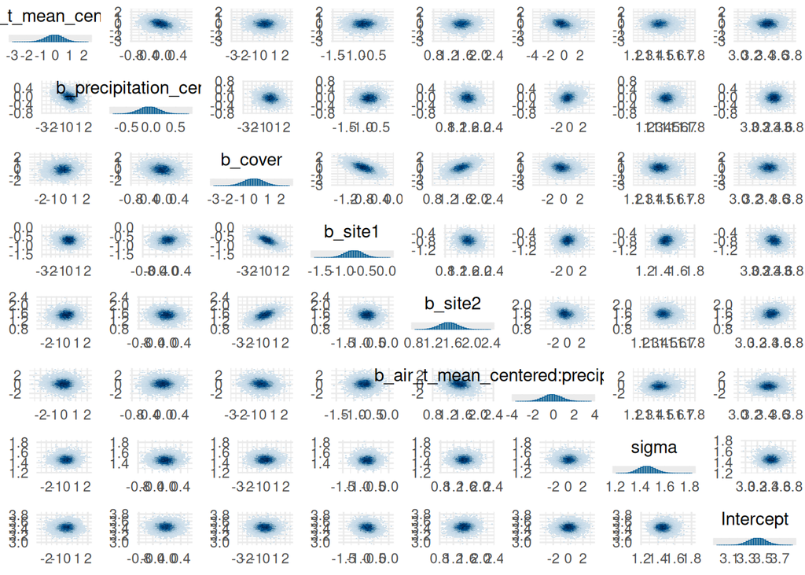

```r
my_mcmc_pairs(fit_ssd_itp)
```

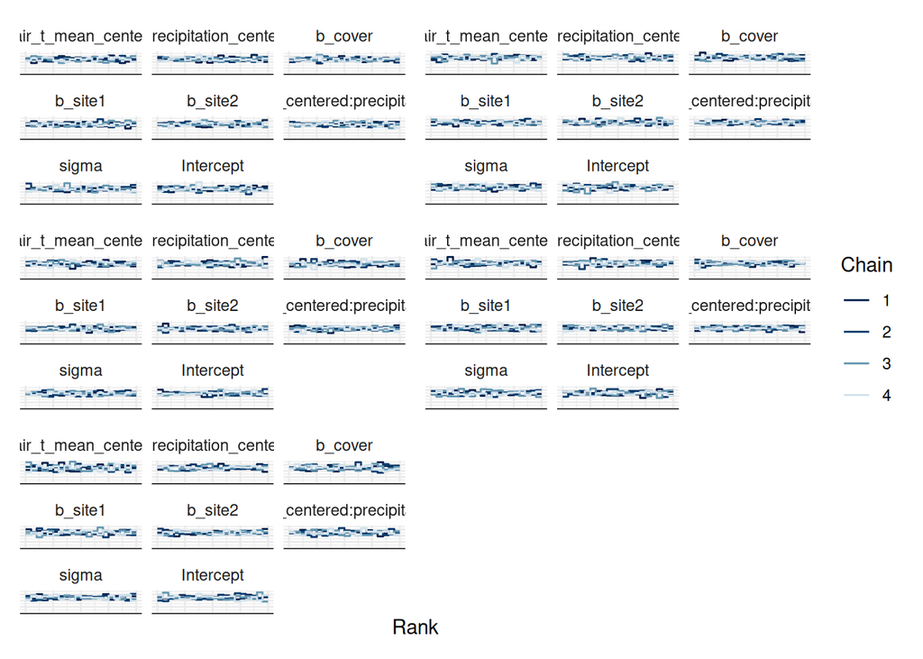

```r
trank(fit_ssd_itp)
```

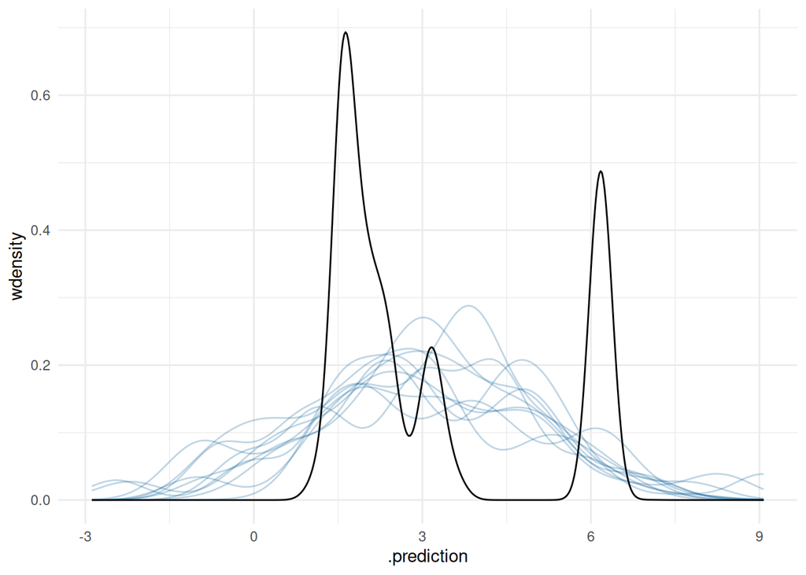

```r
my_ppc(fit_ssd_itp, cwm_ITP$data$ssd, range = F)
```

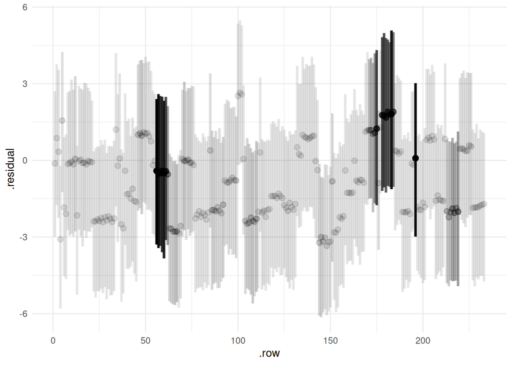

```r
my_resplot(fit_ssd_itp, cwm_ITP$data$ssd[[1]])
```

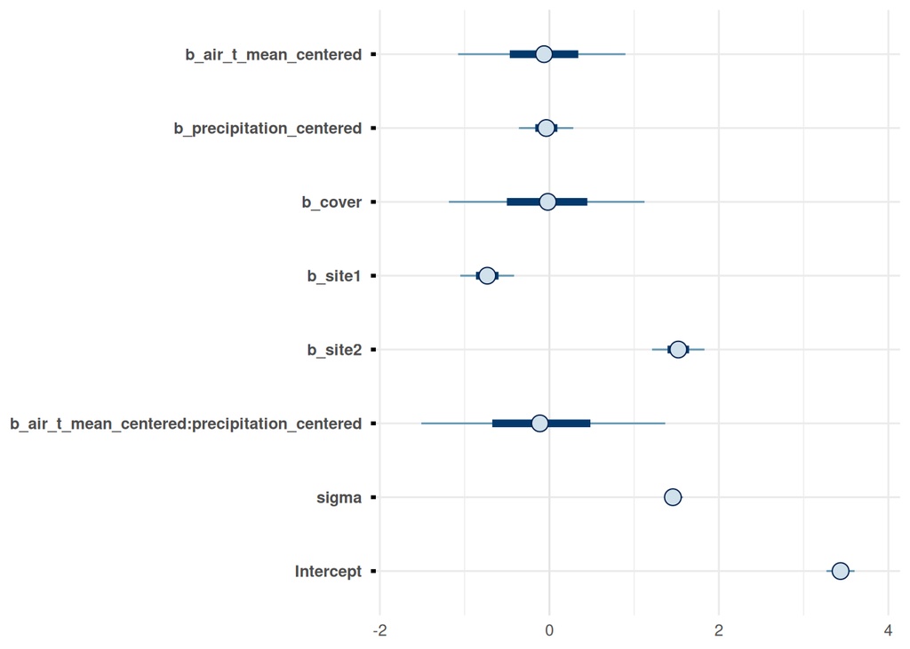

```r
mcmc_intervals(fit_ssd_itp, pars = show)
```

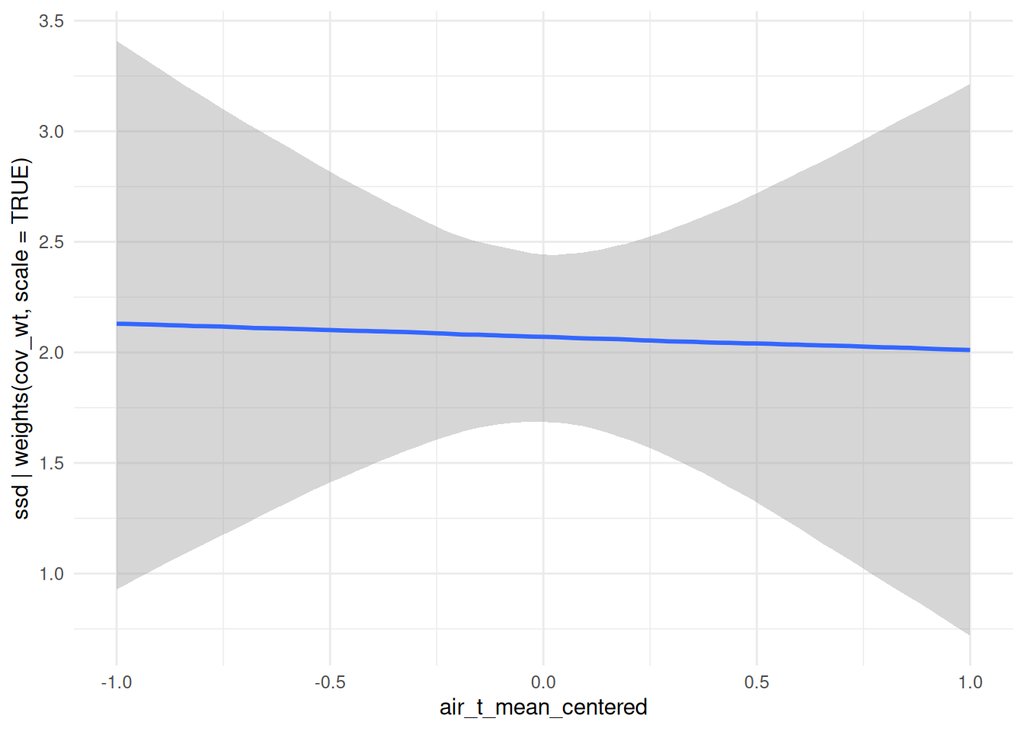

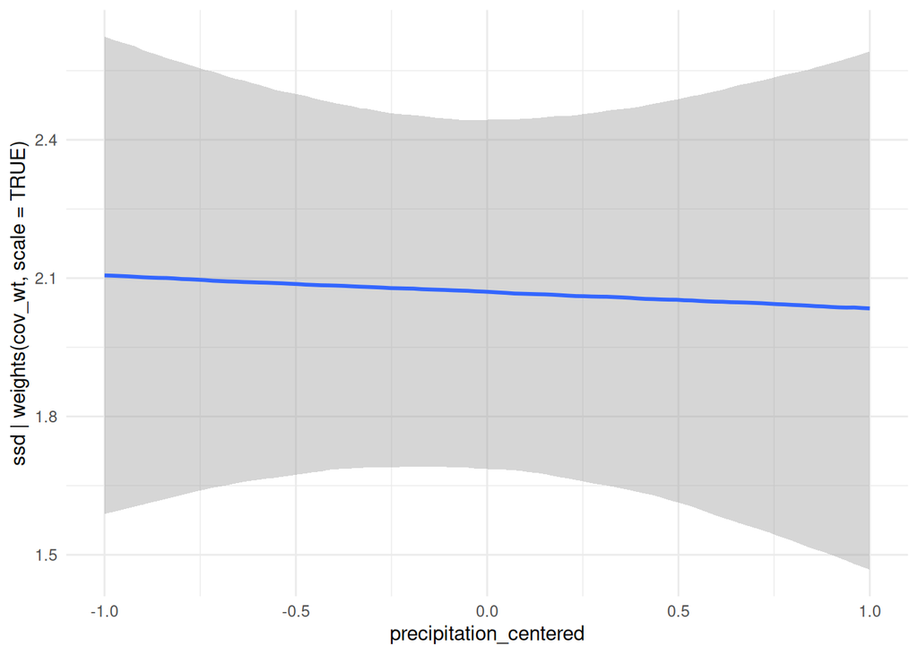

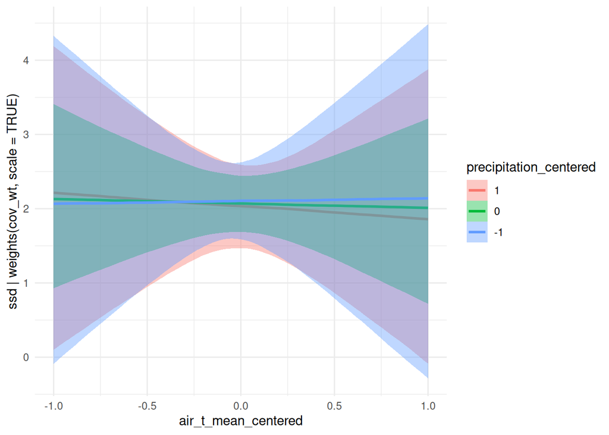

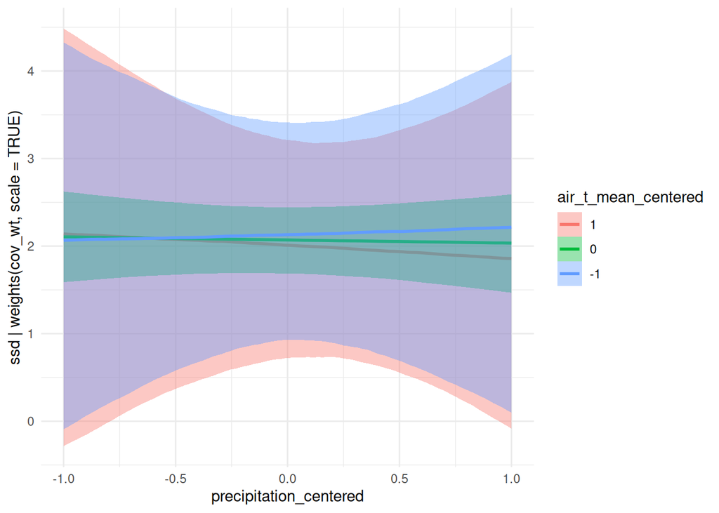

```r
my_ceffects(fit_ssd_itp)
```

## 5.6 Seed mass

Like for SSD, the exceptionally large seed mass of *Ruscus aculeatus* isn’t well accounted for by the data model.

```r
fit_sm_itp <- brm_multiple(sm | weights(cov_wt, scale = TRUE) ~
                             air_t_mean_centered + precipitation_centered +
                             air_t_mean_centered:precipitation_centered + cover + site,
                           data = cwm_ITP$data$sm,
                           prior = prior_ln(cwm_ITP$data$sm[[1]]$sm),
                           family = "lognormal",
                           file = "fits/cwm/sm.itp",
                           file_refit = "never",
                           control = list(seed = 2853))

prior_summary(fit_sm_itp)
```

| prior | class | coef | group | resp | dpar | nlpar | lb | ub | tag | source |
| --- | --- | --- | --- | --- | --- | --- | --- | --- | --- | --- |
| student_t(5, 0, 0.5) | b |  |  |  |  |  |  |  |  | user |
|  | b | air_t_mean_centered |  |  |  |  |  |  |  | default |
|  | b | air_t_mean_centered:precipitation_centered |  |  |  |  |  |  |  | default |
|  | b | cover |  |  |  |  |  |  |  | default |
|  | b | precipitation_centered |  |  |  |  |  |  |  | default |
|  | b | site1 |  |  |  |  |  |  |  | default |
|  | b | site2 |  |  |  |  |  |  |  | default |
| student_t(3, -2.983, 0.6) | Intercept |  |  |  |  |  |  |  |  | user |
| student_t(5, 0, 0.5) | sigma |  |  |  |  |  | 0 |  |  | user |

```r
fit_sm_itp
```

```
 Family: lognormal
  Links: mu = identity
Formula: sm | weights(cov_wt, scale = TRUE) ~ air_t_mean_centered + precipitation_centered + air_t_mean_centered:precipitation_centered + cover + site
   Data: cwm_ITP$data$sm (Number of observations: 266)
  Draws: 20 chains, each with iter = 2000; warmup = 1000; thin = 1;
         total post-warmup draws = 20000

Regression Coefficients:
                                           Estimate Est.Error l-95% CI u-95% CI
Intercept                                     -3.50      1.86    -7.54    -0.18
air_t_mean_centered                           -0.11      0.43    -0.99     0.72
precipitation_centered                         0.04      0.16    -0.27     0.35
cover                                          0.41      0.51    -0.51     1.52
site1                                         -0.10      0.14    -0.37     0.17
site2                                          1.90      0.17     1.58     2.23
air_t_mean_centered:precipitation_centered     0.00      0.54    -1.09     1.09

Further Distributional Parameters:
      Estimate Est.Error l-95% CI u-95% CI
sigma     1.55      0.07     1.42     1.68

Draws were sampled using sample(hmc). Overall Rhat and ESS estimates
are not informative for brm_multiple models and are hence not displayed.
Please see ?brm_multiple for how to assess convergence of such models.
```

```r
multiple_convergence(fit_sm_itp)
```

| variable | rhat | ess_bulk | ess_tail |
| --- | --- | --- | --- |
| b_Intercept | 1 | 3096 | 2395 |
| b_air_t_mean_centered | 1 | 5030 | 2347 |
| b_precipitation_centered | 1 | 4896 | 2785 |
| b_cover | 1 | 3083 | 2496 |
| b_site1 | 1 | 4345 | 2882 |
| b_site2 | 1 | 3421 | 2896 |
| b_air_t_mean_centered:precipitation_centered | 1 | 4779 | 2479 |
| sigma | 1 | 5142 | 2778 |
| Intercept | 1 | 5129 | 2889 |

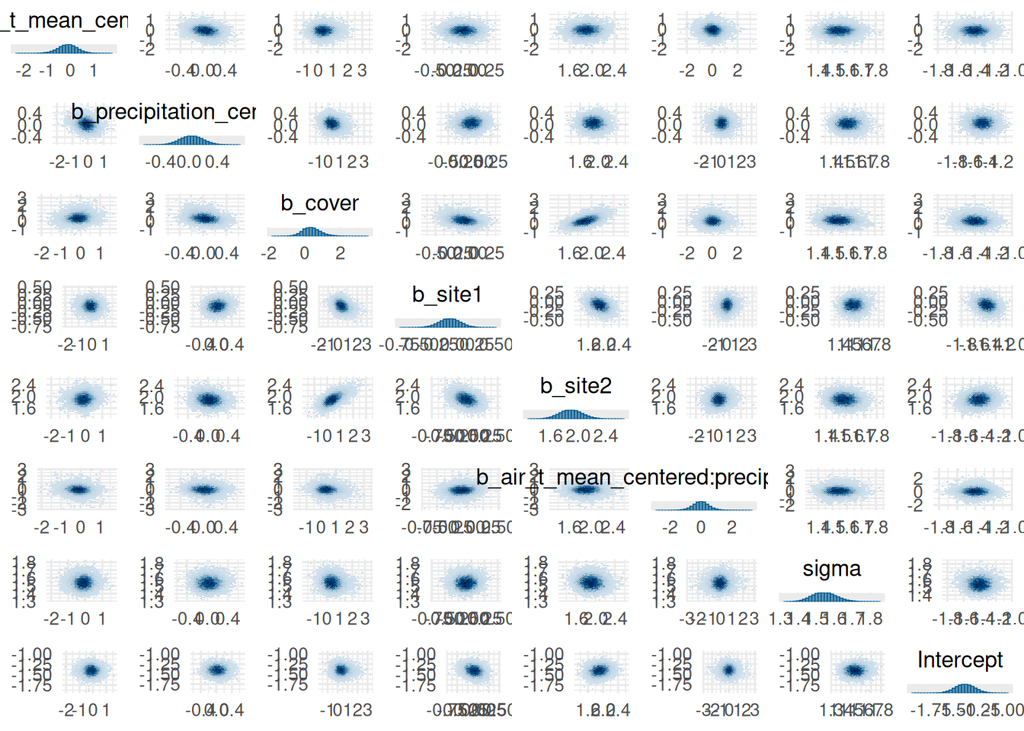

```r
my_mcmc_pairs(fit_sm_itp)
```

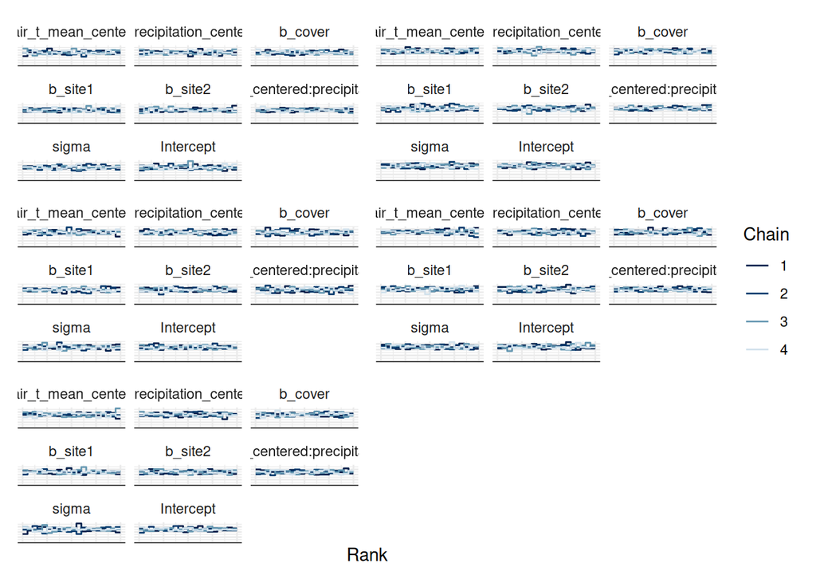

```r
trank(fit_sm_itp)
```

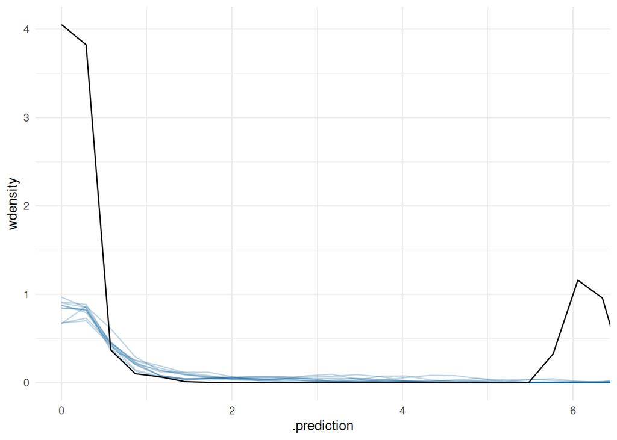

```r
my_ppc(fit_sm_itp, cwm_ITP$data$sm)
```

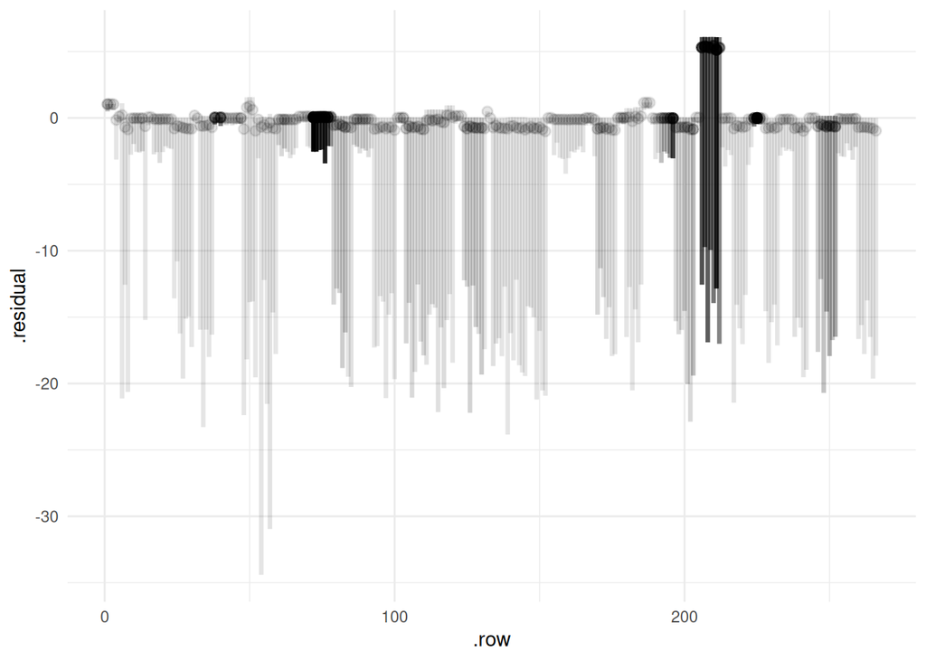

```r
my_resplot(fit_sm_itp, cwm_ITP$data$sm[[1]])
```

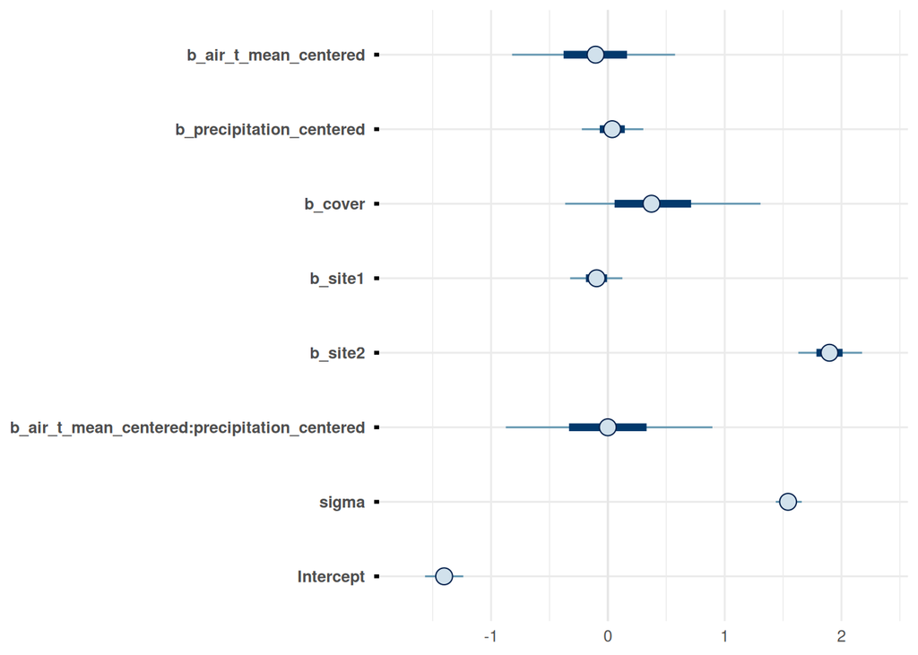

```r
mcmc_intervals(fit_sm_itp, pars = show)
```

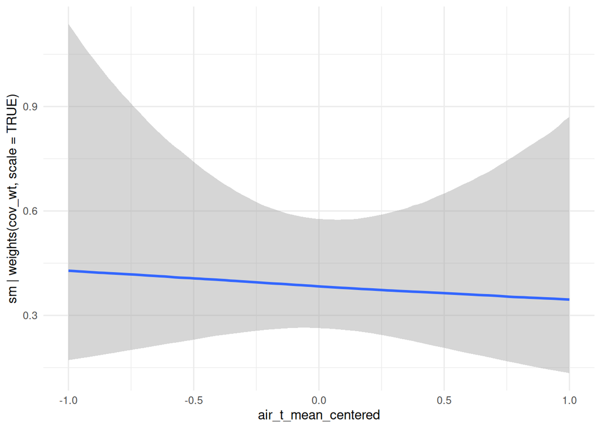

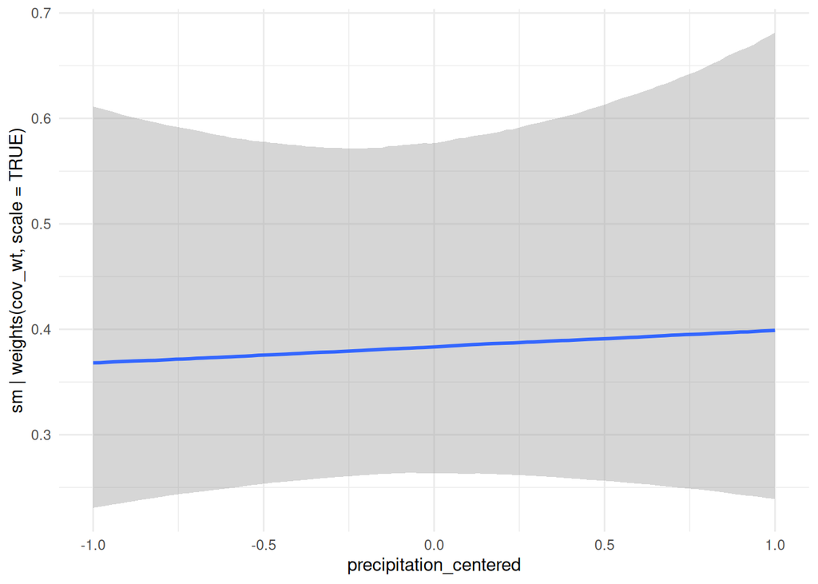

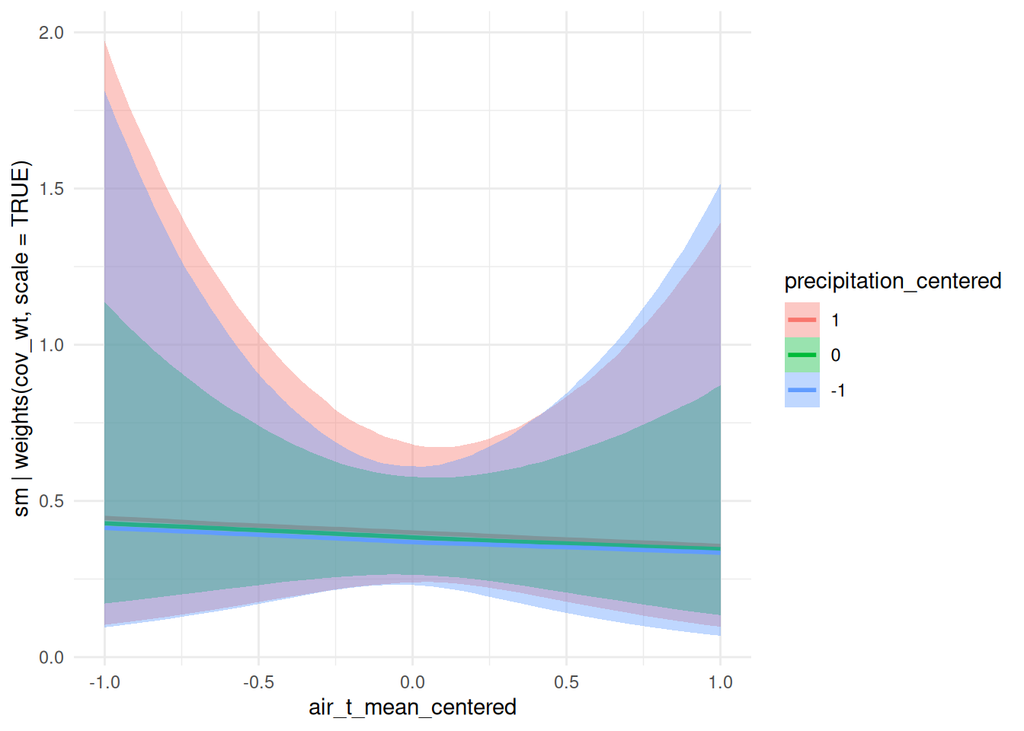

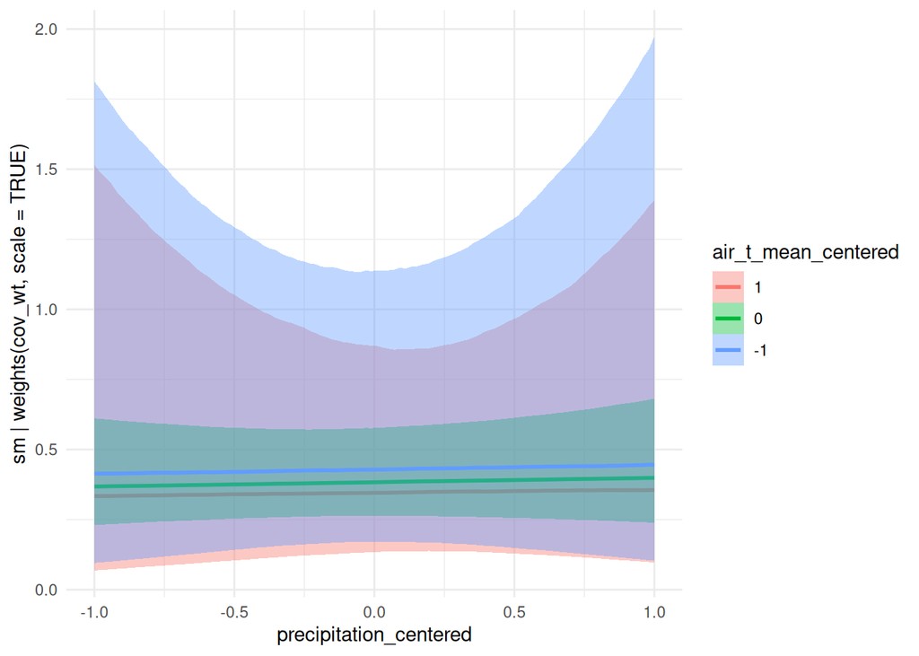

```r
my_ceffects(fit_sm_itp)
```

## 5.7 Bud Bank (incl. root)

While this clonal trait is in principle a discrete count (bud in BB organs per rooting unit), its averaging across measurements and datasets results in a variable which is more similar to continuous. This supports the use of Gaussian models, because the outcome is not a discrete count. Similar considerations apply to multiplication rate and persistence.

```r
fit_bbr_itp <- brm_multiple(BBRsize | weights(cov_wt, scale = TRUE) ~
                              soil_t_mean_centered + precipitation_centered +
                              soil_t_mean_centered:precipitation_centered + cover + site,
                            data = cwm_ITP$data$BBRsize,
                            prior = prior_ln(cwm_ITP$data$BBRsize[[1]]$BBRsize),
                            file = "fits/cwm/BBRsize.itp",
                            file_refit = "never",
                            control = list(seed = 2853))

prior_summary(fit_bbr_itp)
```

| prior | class | coef | group | resp | dpar | nlpar | lb | ub | tag | source |
| --- | --- | --- | --- | --- | --- | --- | --- | --- | --- | --- |
| student_t(5, 0, 0.5) | b |  |  |  |  |  |  |  |  | user |
|  | b | cover |  |  |  |  |  |  |  | default |
|  | b | precipitation_centered |  |  |  |  |  |  |  | default |
|  | b | site1 |  |  |  |  |  |  |  | default |
|  | b | site2 |  |  |  |  |  |  |  | default |
|  | b | soil_t_mean_centered |  |  |  |  |  |  |  | default |
|  | b | soil_t_mean_centered:precipitation_centered |  |  |  |  |  |  |  | default |
| student_t(3, 0.651, 0.6) | Intercept |  |  |  |  |  |  |  |  | user |
| student_t(5, 0, 0.5) | sigma |  |  |  |  |  | 0 |  |  | user |

```r
fit_bbr_itp
```

```
 Family: gaussian
  Links: mu = identity
Formula: BBRsize | weights(cov_wt, scale = TRUE) ~ soil_t_mean_centered + precipitation_centered + soil_t_mean_centered:precipitation_centered + cover + site
   Data: cwm_ITP$data$BBRsize (Number of observations: 373)
  Draws: 20 chains, each with iter = 2000; warmup = 1000; thin = 1;
         total post-warmup draws = 20000

Regression Coefficients:
                                            Estimate Est.Error l-95% CI
Intercept                                       4.71      1.30     2.29
soil_t_mean_centered                           -0.36      0.35    -1.05
precipitation_centered                          0.08      0.08    -0.07
cover                                          -0.78      0.36    -1.52
site1                                           0.41      0.06     0.29
site2                                          -0.64      0.09    -0.83
soil_t_mean_centered:precipitation_centered     0.42      0.42    -0.37
                                            u-95% CI
Intercept                                       7.36
soil_t_mean_centered                            0.31
precipitation_centered                          0.23
cover                                          -0.11
site1                                           0.54
site2                                          -0.47
soil_t_mean_centered:precipitation_centered     1.27

Further Distributional Parameters:
      Estimate Est.Error l-95% CI u-95% CI
sigma     0.78      0.03     0.72     0.83

Draws were sampled using sample(hmc). Overall Rhat and ESS estimates
are not informative for brm_multiple models and are hence not displayed.
Please see ?brm_multiple for how to assess convergence of such models.
```

```r
multiple_convergence(fit_bbr_itp)
```

| variable | rhat | ess_bulk | ess_tail |
| --- | --- | --- | --- |
| b_Intercept | 1 | 2498 | 2533 |
| b_soil_t_mean_centered | 1 | 3014 | 2617 |
| b_precipitation_centered | 1 | 3179 | 2648 |
| b_cover | 1 | 2498 | 2585 |
| b_site1 | 1 | 2621 | 2850 |
| b_site2 | 1 | 2098 | 2388 |
| b_soil_t_mean_centered:precipitation_centered | 1 | 3341 | 2646 |
| sigma | 1 | 3950 | 2715 |
| Intercept | 1 | 3833 | 2767 |

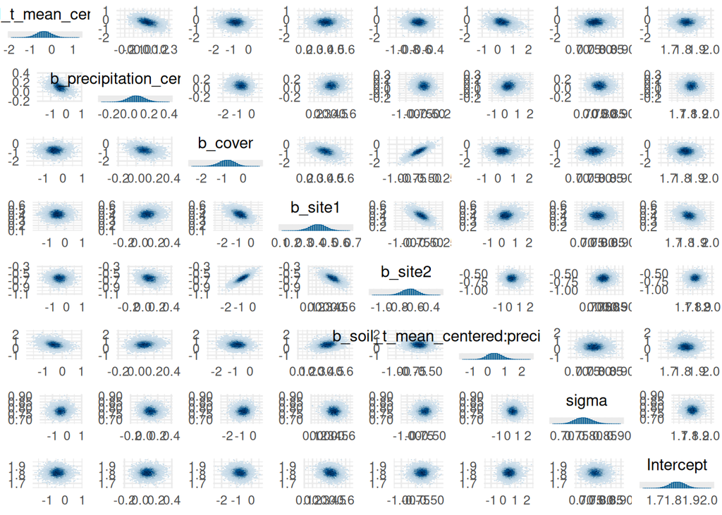

```r
my_mcmc_pairs(fit_bbr_itp)
```

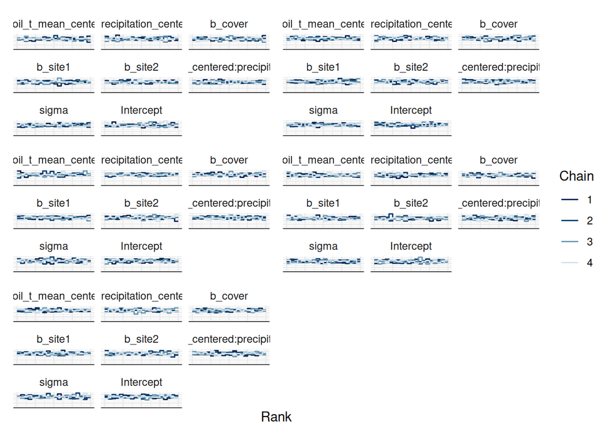

```r
trank(fit_bbr_itp)
```

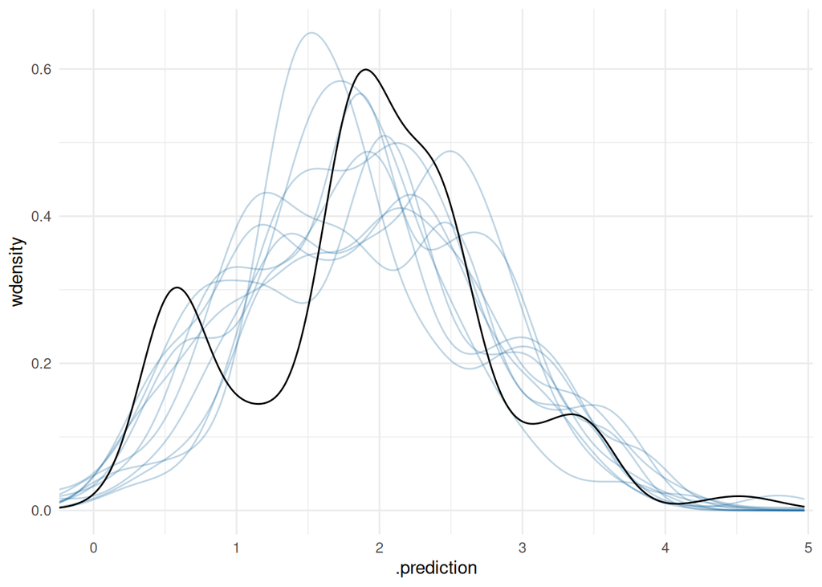

```r
my_ppc(fit_bbr_itp, cwm_ITP$data$BBRsize)
```

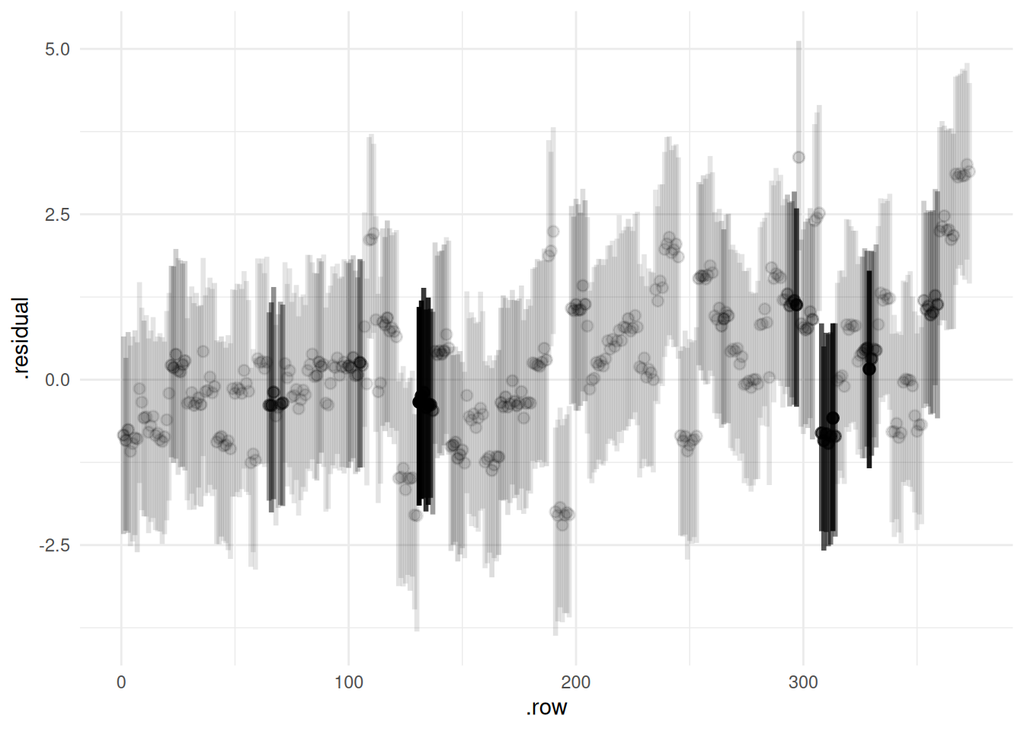

```r
my_resplot(fit_bbr_itp, cwm_ITP$data$BBRsize[[1]])
```

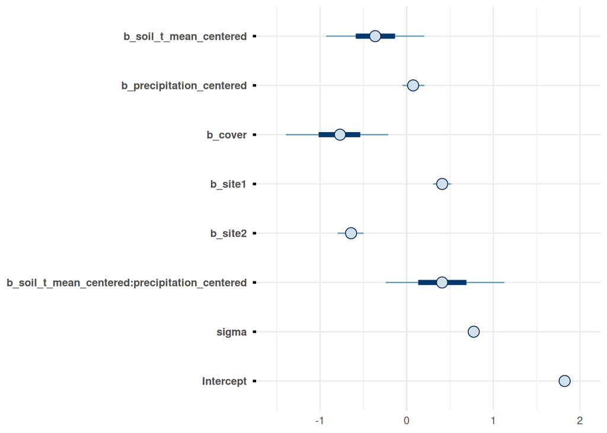

```r
mcmc_intervals(fit_bbr_itp, pars = show)
```

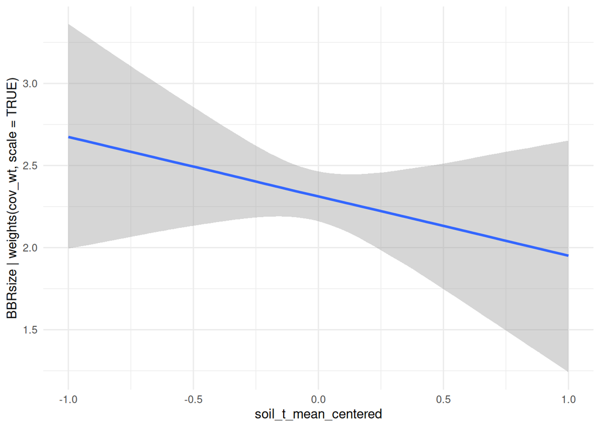

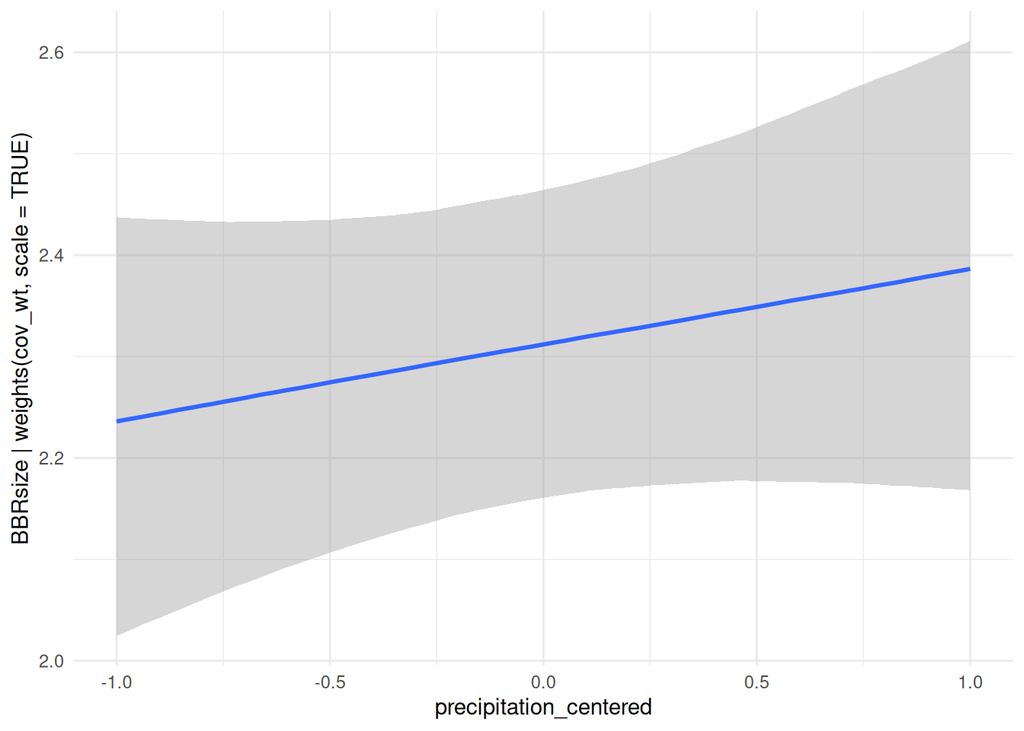

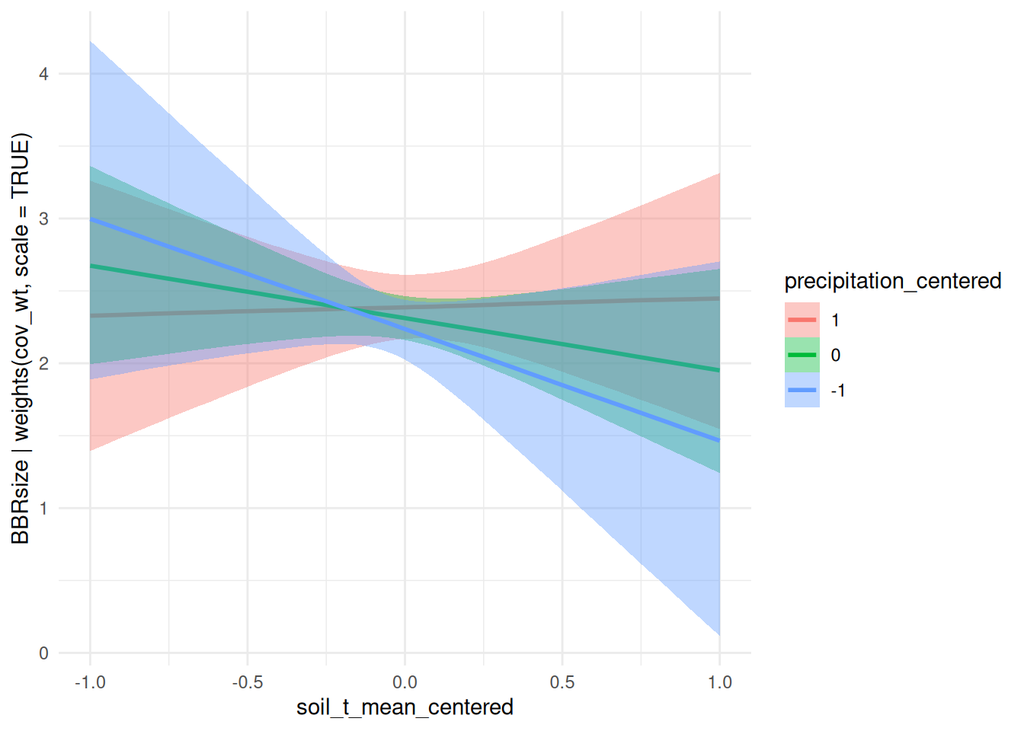

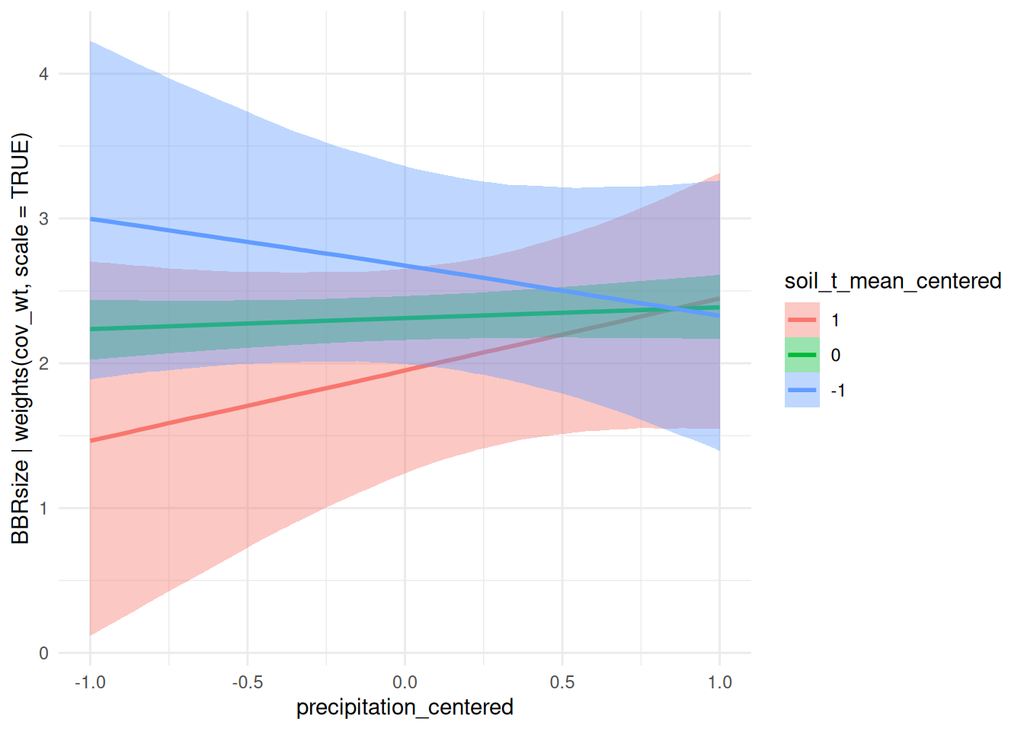

```r
my_ceffects(fit_bbr_itp)
```

## 5.8 Multiplication rate

```r
fit_off_itp <- brm_multiple(bf(offspring | weights(cov_wt, scale = TRUE) ~
                                        soil_t_mean_centered + precipitation_centered +
                                        soil_t_mean_centered:precipitation_centered + cover + site,
                                      hu ~ soil_t_mean_centered + precipitation_centered +
                                        soil_t_mean_centered:precipitation_centered + cover + site),
             data = cwm_ITP$data$offspring,
             prior = prior_ln(cwm_ITP$data$offspring[[1]]$offspring, hu = T),
             family = "hurdle_lognormal",
             file = "fits/cwm/offspring.itp",
             file_refit = "never",
             control = list(seed = 2853))

prior_summary(fit_off_itp)
```

| prior | class | coef | group | resp | dpar | nlpar | lb | ub | tag | source |
| --- | --- | --- | --- | --- | --- | --- | --- | --- | --- | --- |
| student_t(5, 0, 0.5) | b |  |  |  |  |  |  |  |  | user |
|  | b | cover |  |  |  |  |  |  |  | default |
|  | b | precipitation_centered |  |  |  |  |  |  |  | default |
|  | b | site1 |  |  |  |  |  |  |  | default |
|  | b | site2 |  |  |  |  |  |  |  | default |
|  | b | soil_t_mean_centered |  |  |  |  |  |  |  | default |
|  | b | soil_t_mean_centered:precipitation_centered |  |  |  |  |  |  |  | default |
| normal(0, 1) | b |  |  |  | hu |  |  |  |  | user |
|  | b | cover |  |  | hu |  |  |  |  | default |
|  | b | precipitation_centered |  |  | hu |  |  |  |  | default |
|  | b | site1 |  |  | hu |  |  |  |  | default |
|  | b | site2 |  |  | hu |  |  |  |  | default |
|  | b | soil_t_mean_centered |  |  | hu |  |  |  |  | default |
|  | b | soil_t_mean_centered:precipitation_centered |  |  | hu |  |  |  |  | default |
| student_t(3, -0.484, 0.6) | Intercept |  |  |  |  |  |  |  |  | user |
| logistic(0, 1) | Intercept |  |  |  | hu |  |  |  |  | default |
| student_t(5, 0, 0.5) | sigma |  |  |  |  |  | 0 |  |  | user |

```r
fit_off_itp
```

```
 Family: hurdle_lognormal
  Links: mu = identity; hu = logit
Formula: offspring | weights(cov_wt, scale = TRUE) ~ soil_t_mean_centered + precipitation_centered + soil_t_mean_centered:precipitation_centered + cover + site
         hu ~ soil_t_mean_centered + precipitation_centered + soil_t_mean_centered:precipitation_centered + cover + site
   Data: cwm_ITP$data$offspring (Number of observations: 373)
  Draws: 20 chains, each with iter = 2000; warmup = 1000; thin = 1;
         total post-warmup draws = 20000

Regression Coefficients:
                                               Estimate Est.Error l-95% CI
Intercept                                          1.72      1.10    -0.41
hu_Intercept                                      -3.91      3.32   -10.35
soil_t_mean_centered                               0.04      0.32    -0.56
precipitation_centered                            -0.13      0.07    -0.26
cover                                             -0.43      0.30    -1.04
site1                                              0.06      0.06    -0.04
site2                                              0.10      0.08    -0.06
soil_t_mean_centered:precipitation_centered       -0.03      0.43    -0.89
hu_soil_t_mean_centered                            0.15      0.94    -1.70
hu_precipitation_centered                          0.06      0.40    -0.75
hu_cover                                           0.12      0.91    -1.67
hu_site1                                          -0.45      0.42    -1.33
hu_site2                                          -0.09      0.41    -0.91
hu_soil_t_mean_centered:precipitation_centered     0.05      0.97    -1.84
                                               u-95% CI
Intercept                                          3.92
hu_Intercept                                       2.53
soil_t_mean_centered                               0.70
precipitation_centered                             0.01
cover                                              0.16
site1                                              0.18
site2                                              0.25
soil_t_mean_centered:precipitation_centered        0.80
hu_soil_t_mean_centered                            1.97
hu_precipitation_centered                          0.84
hu_cover                                           1.88
hu_site1                                           0.32
hu_site2                                           0.71
hu_soil_t_mean_centered:precipitation_centered     1.97

Further Distributional Parameters:
      Estimate Est.Error l-95% CI u-95% CI
sigma     0.67      0.03     0.62     0.72

Draws were sampled using sample(hmc). Overall Rhat and ESS estimates
are not informative for brm_multiple models and are hence not displayed.
Please see ?brm_multiple for how to assess convergence of such models.
```

```r
multiple_convergence(fit_off_itp)
```

| variable | rhat | ess_bulk | ess_tail |
| --- | --- | --- | --- |
| b_Intercept | 1 | 2627 | 2524 |
| b_hu_Intercept | 1 | 4173 | 3004 |
| b_soil_t_mean_centered | 1 | 4123 | 3042 |
| b_precipitation_centered | 1 | 3610 | 3020 |
| b_cover | 1 | 2610 | 2507 |
| b_site1 | 1 | 3129 | 2942 |
| b_site2 | 1 | 2655 | 2427 |
| b_soil_t_mean_centered:precipitation_centered | 1 | 4359 | 2742 |
| b_hu_soil_t_mean_centered | 1 | 4615 | 2686 |
| b_hu_precipitation_centered | 1 | 3897 | 2835 |
| b_hu_cover | 1 | 4183 | 3047 |
| b_hu_site1 | 1 | 3015 | 2840 |
| b_hu_site2 | 1 | 3167 | 2684 |
| b_hu_soil_t_mean_centered:precipitation_centered | 1 | 4954 | 2815 |
| sigma | 1 | 4597 | 2648 |
| Intercept | 1 | 3998 | 2704 |
| Intercept_hu | 1 | 4406 | 2537 |

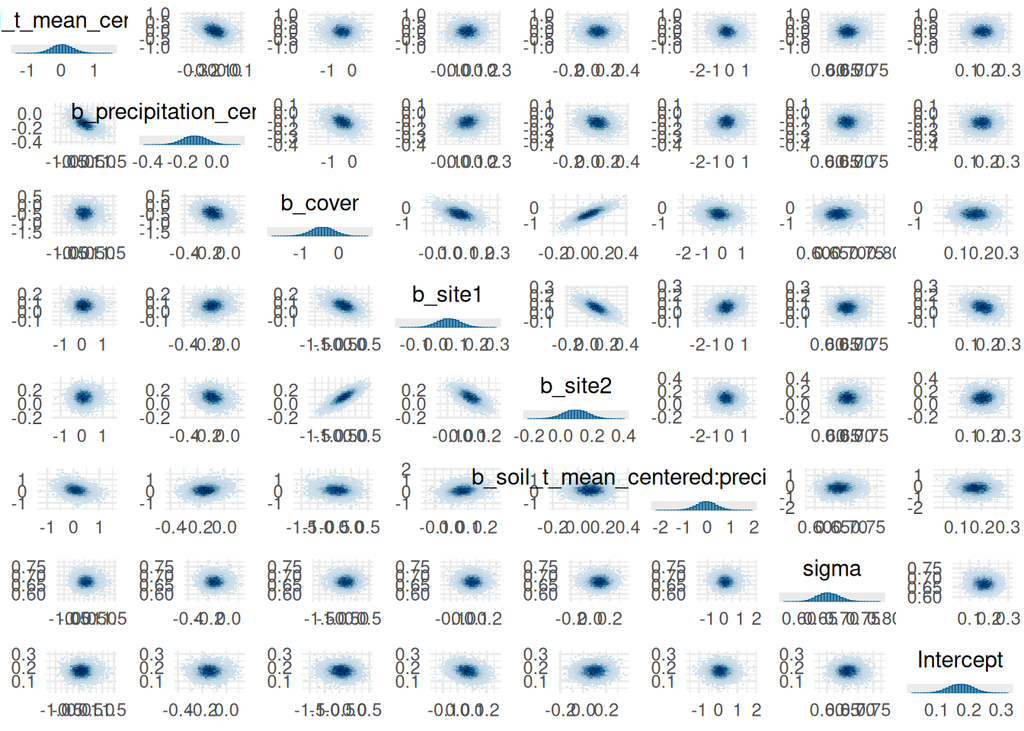

```r
my_mcmc_pairs(fit_off_itp, vars(!contains(c("hu", "lp", "b_Intercept"))))
```

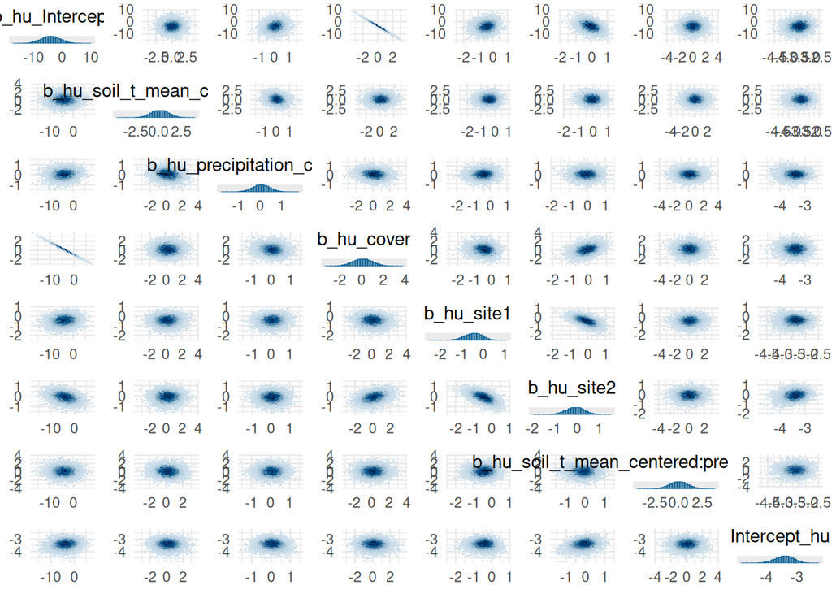

```r
my_mcmc_pairs(fit_off_itp, pars = vars(contains("hu")))
```

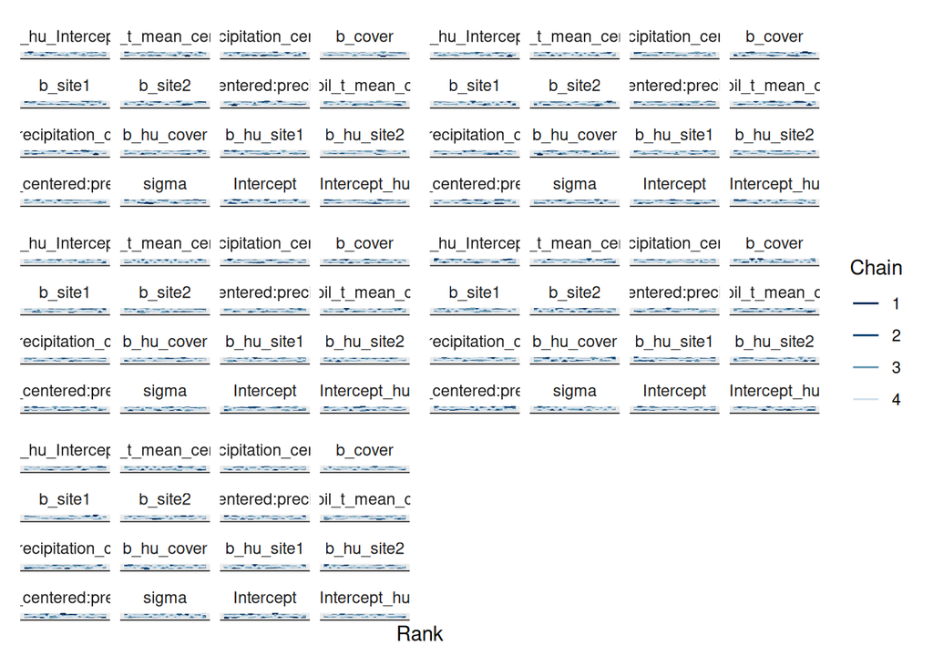

```r
trank(fit_off_itp)
```

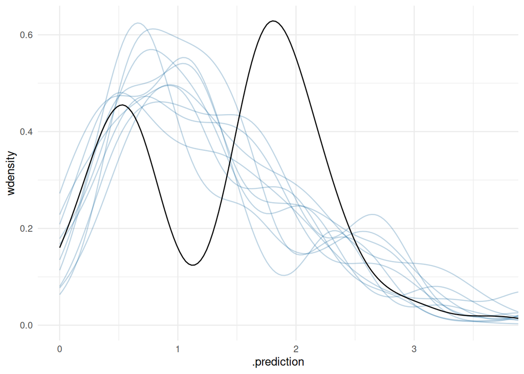

```r
my_ppc(fit_off_itp, cwm_ITP$data$offspring)
```

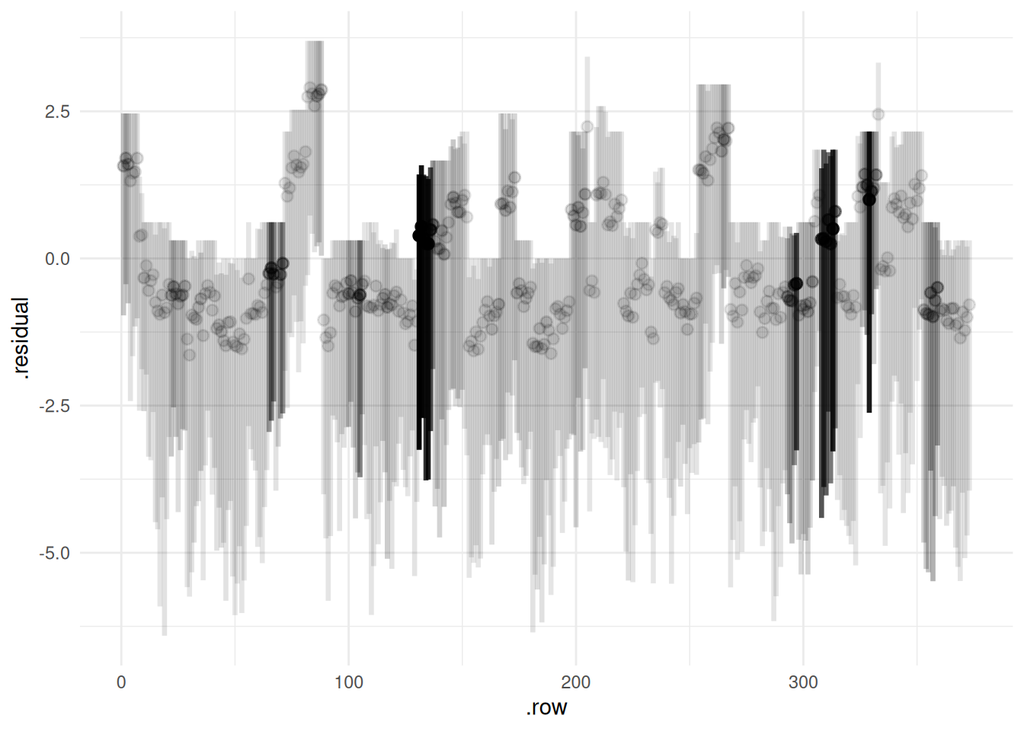

```r
my_resplot(fit_off_itp, cwm_ITP$data$offspring[[1]])
```

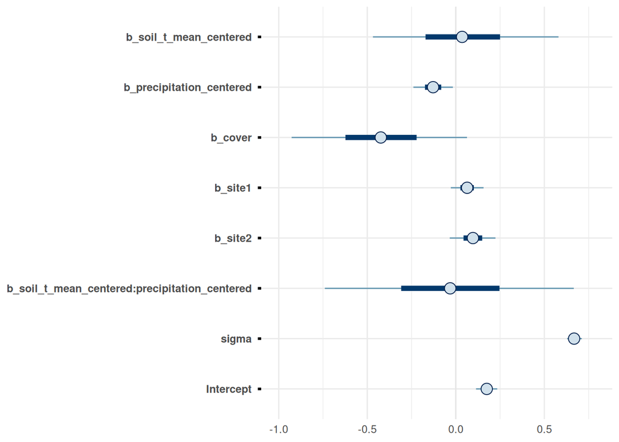

```r
mcmc_intervals(fit_off_itp, pars = vars(!contains(c("hu", "lp", "b_Intercept"))))
```

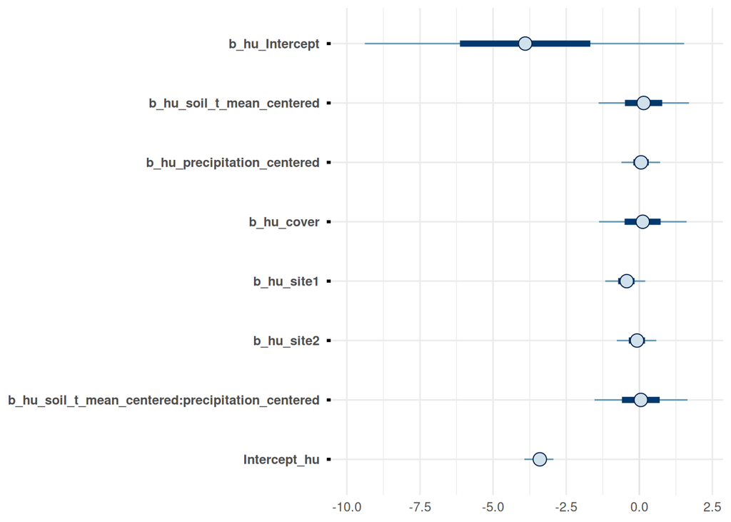

```r
mcmc_intervals(fit_off_itp, pars = vars(contains("hu")))
```

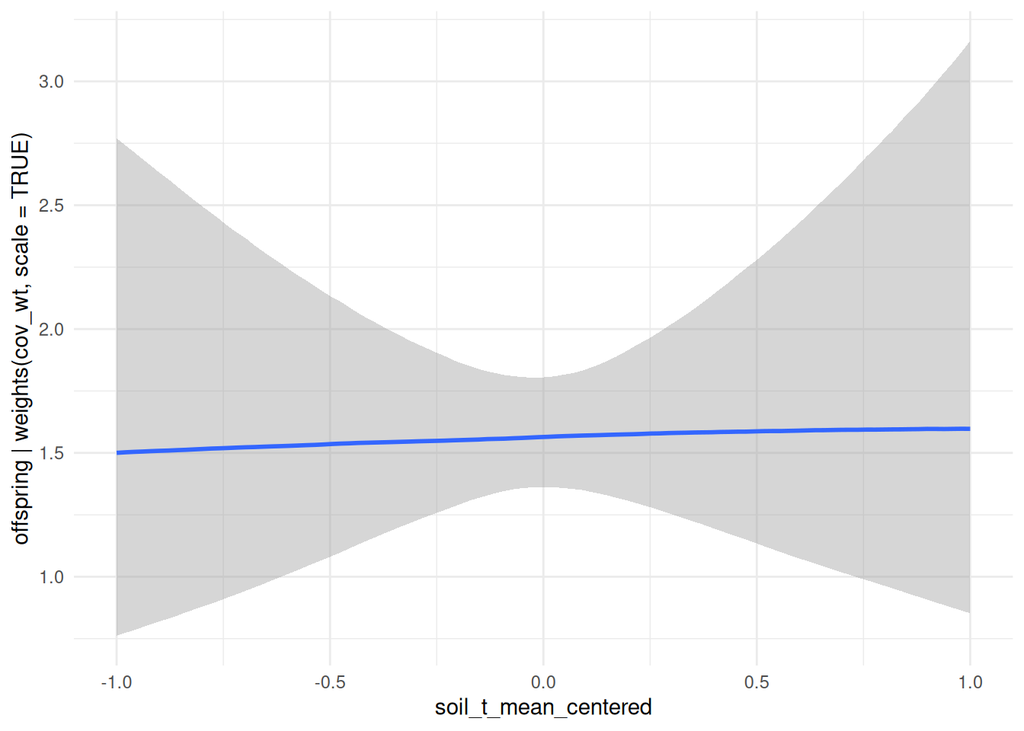

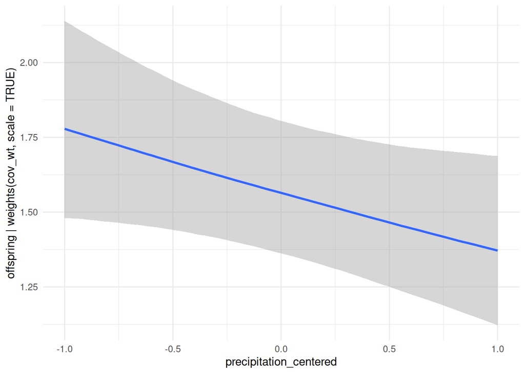

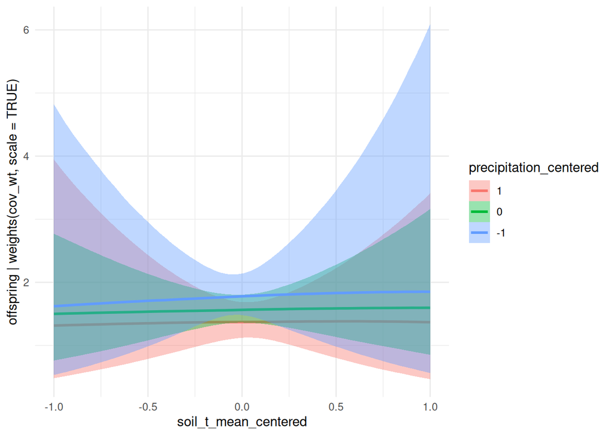

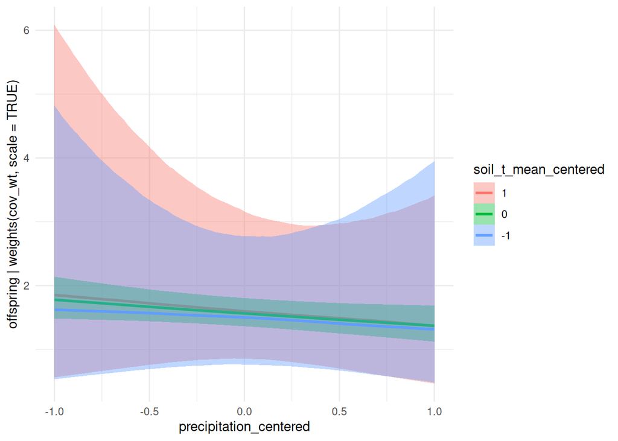

```r
my_ceffects(fit_off_itp, hurdle = T)
```

## 5.9 Lateral spread

```r
fit_spread_itp <- brm_multiple(bf(spread | weights(cov_wt, scale = TRUE) ~
                                    soil_t_mean_centered + precipitation_centered +
                                    soil_t_mean_centered:precipitation_centered + cover + site,
                                  hu ~ soil_t_mean_centered + precipitation_centered +
                                    soil_t_mean_centered:precipitation_centered + cover + site),
                               data = cwm_ITP$data$spread,
                               prior = prior_ln(cwm_ITP$data$spread[[1]]$spread, hu = T),
                               family = "hurdle_lognormal",
                               file = "fits/cwm/spread.itp",
                               file_refit = "never",
                               control = list(seed = 2853))

prior_summary(fit_spread_itp)
```

| prior | class | coef | group | resp | dpar | nlpar | lb | ub | tag | source |
| --- | --- | --- | --- | --- | --- | --- | --- | --- | --- | --- |
| student_t(5, 0, 0.5) | b |  |  |  |  |  |  |  |  | user |
|  | b | cover |  |  |  |  |  |  |  | default |
|  | b | precipitation_centered |  |  |  |  |  |  |  | default |
|  | b | site1 |  |  |  |  |  |  |  | default |
|  | b | site2 |  |  |  |  |  |  |  | default |
|  | b | soil_t_mean_centered |  |  |  |  |  |  |  | default |
|  | b | soil_t_mean_centered:precipitation_centered |  |  |  |  |  |  |  | default |
| normal(0, 1) | b |  |  |  | hu |  |  |  |  | user |
|  | b | cover |  |  | hu |  |  |  |  | default |
|  | b | precipitation_centered |  |  | hu |  |  |  |  | default |
|  | b | site1 |  |  | hu |  |  |  |  | default |
|  | b | site2 |  |  | hu |  |  |  |  | default |
|  | b | soil_t_mean_centered |  |  | hu |  |  |  |  | default |
|  | b | soil_t_mean_centered:precipitation_centered |  |  | hu |  |  |  |  | default |
| student_t(3, -0.993, 0.6) | Intercept |  |  |  |  |  |  |  |  | user |
| logistic(0, 1) | Intercept |  |  |  | hu |  |  |  |  | default |
| student_t(5, 0, 0.5) | sigma |  |  |  |  |  | 0 |  |  | user |

```r
fit_spread_itp
```

```
 Family: hurdle_lognormal
  Links: mu = identity; hu = logit
Formula: spread | weights(cov_wt, scale = TRUE) ~ soil_t_mean_centered + precipitation_centered + soil_t_mean_centered:precipitation_centered + cover + site
         hu ~ soil_t_mean_centered + precipitation_centered + soil_t_mean_centered:precipitation_centered + cover + site
   Data: cwm_ITP$data$spread (Number of observations: 373)
  Draws: 20 chains, each with iter = 2000; warmup = 1000; thin = 1;
         total post-warmup draws = 20000

Regression Coefficients:
                                               Estimate Est.Error l-95% CI
Intercept                                          1.14      1.77    -2.04
hu_Intercept                                      -3.93      3.35   -10.45
soil_t_mean_centered                              -0.39      0.50    -1.45
precipitation_centered                            -0.05      0.12    -0.28
cover                                             -0.54      0.49    -1.61
site1                                              0.54      0.10     0.34
site2                                             -0.63      0.14    -0.91
soil_t_mean_centered:precipitation_centered        0.28      0.60    -0.76
hu_soil_t_mean_centered                            0.12      0.95    -1.74
hu_precipitation_centered                          0.06      0.41    -0.77
hu_cover                                           0.12      0.92    -1.65
hu_site1                                          -0.46      0.42    -1.34
hu_site2                                          -0.08      0.42    -0.93
hu_soil_t_mean_centered:precipitation_centered    -0.01      0.98    -1.93
                                               u-95% CI
Intercept                                          5.02
hu_Intercept                                       2.49
soil_t_mean_centered                               0.51
precipitation_centered                             0.19
cover                                              0.34
site1                                              0.75
site2                                             -0.37
soil_t_mean_centered:precipitation_centered        1.64
hu_soil_t_mean_centered                            1.98
hu_precipitation_centered                          0.85
hu_cover                                           1.91
hu_site1                                           0.34
hu_site2                                           0.73
hu_soil_t_mean_centered:precipitation_centered     1.90

Further Distributional Parameters:
      Estimate Est.Error l-95% CI u-95% CI
sigma     1.32      0.05     1.22     1.42

Draws were sampled using sample(hmc). Overall Rhat and ESS estimates
are not informative for brm_multiple models and are hence not displayed.
Please see ?brm_multiple for how to assess convergence of such models.
```

```r
multiple_convergence(fit_spread_itp)
```

| variable | rhat | ess_bulk | ess_tail |
| --- | --- | --- | --- |
| b_Intercept | 1 | 2629 | 2310 |
| b_hu_Intercept | 1 | 4231 | 3089 |
| b_soil_t_mean_centered | 1 | 3789 | 2409 |
| b_precipitation_centered | 1 | 3775 | 3051 |
| b_cover | 1 | 2623 | 2326 |
| b_site1 | 1 | 2956 | 2884 |
| b_site2 | 1 | 2264 | 2239 |
| b_soil_t_mean_centered:precipitation_centered | 1 | 3905 | 2044 |
| b_hu_soil_t_mean_centered | 1 | 4505 | 2581 |
| b_hu_precipitation_centered | 1 | 4222 | 2936 |
| b_hu_cover | 1 | 4268 | 3168 |
| b_hu_site1 | 1 | 3185 | 2490 |
| b_hu_site2 | 1 | 3201 | 2518 |
| b_hu_soil_t_mean_centered:precipitation_centered | 1 | 4954 | 2954 |
| sigma | 1 | 5088 | 2956 |
| Intercept | 1 | 4746 | 3214 |
| Intercept_hu | 1 | 4133 | 2798 |

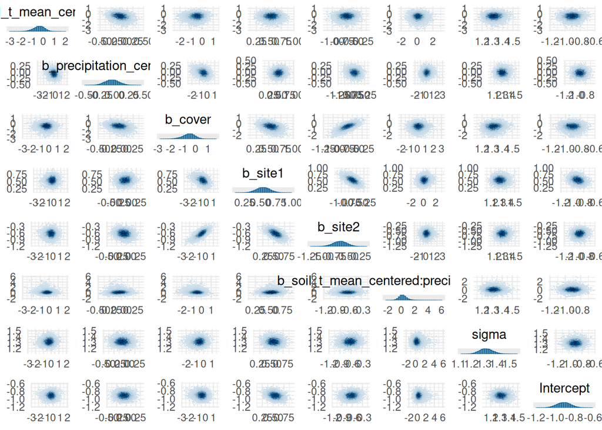

```r
my_mcmc_pairs(fit_spread_itp, vars(!contains(c("hu", "lp", "b_Intercept"))))
```

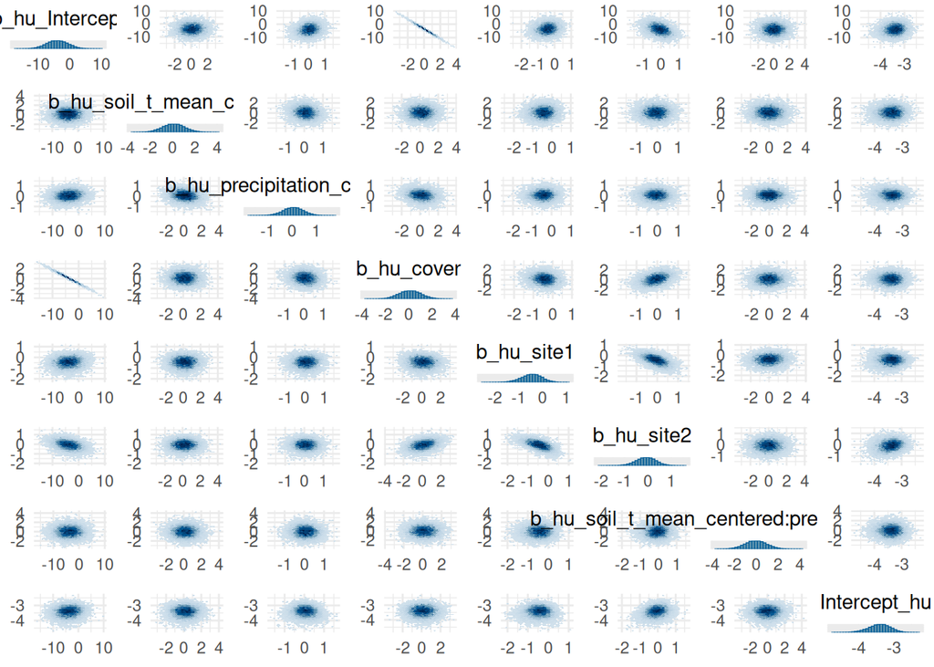

```r
my_mcmc_pairs(fit_spread_itp, pars = vars(contains("hu")))
```

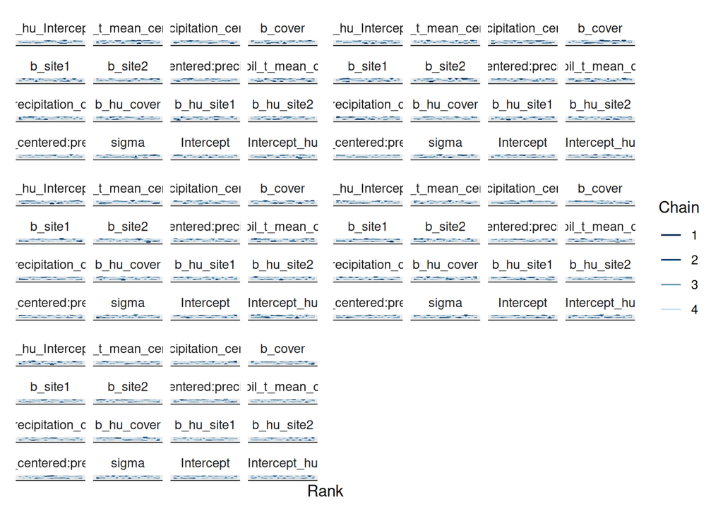

```r
trank(fit_spread_itp)
```

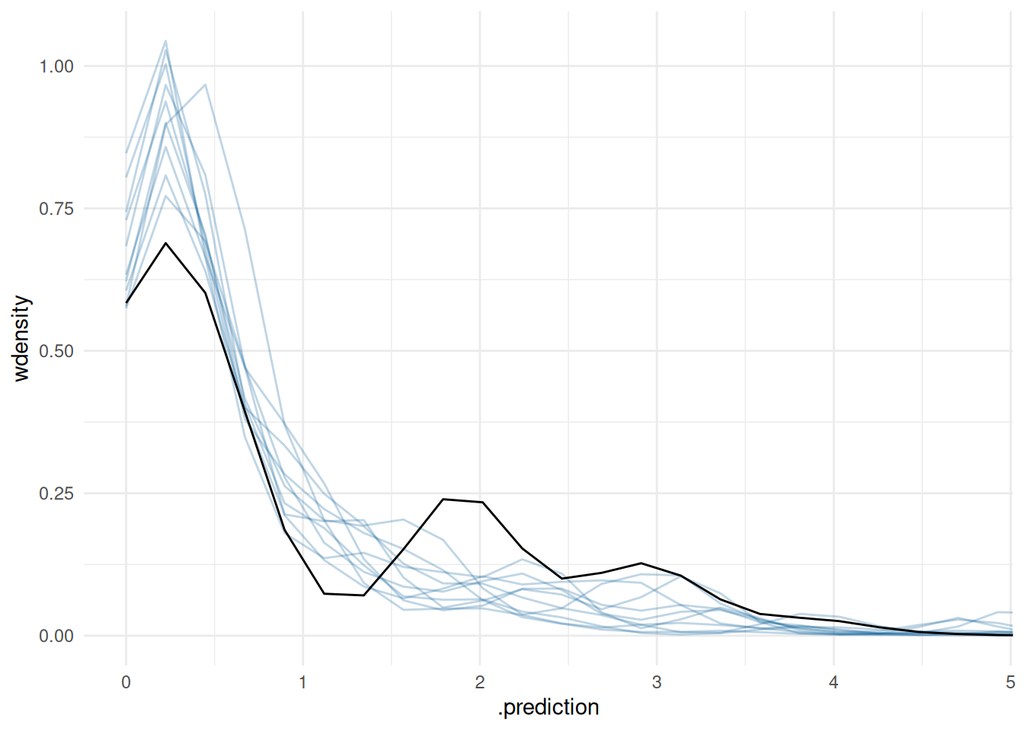

```r
my_ppc(fit_spread_itp, cwm_ITP$data$spread)
```

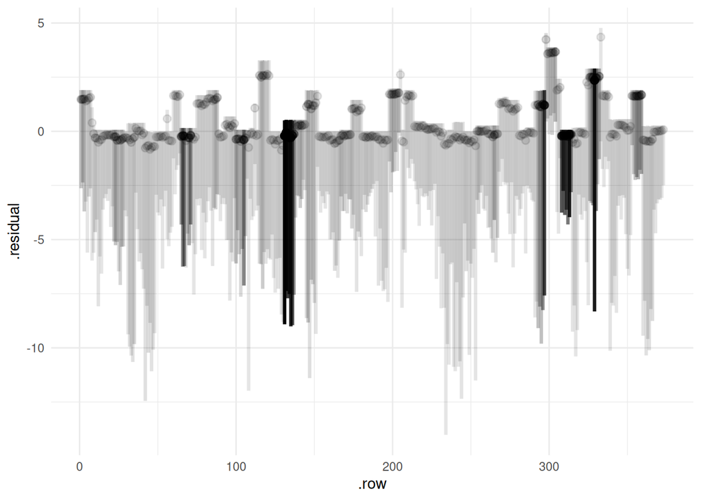

```r
my_resplot(fit_spread_itp, cwm_ITP$data$spread[[1]])
```

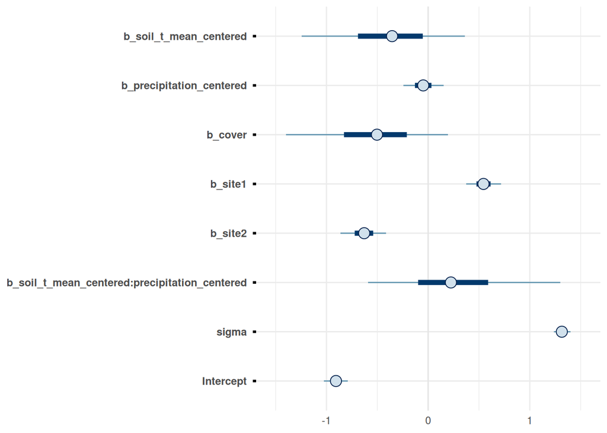

```r
mcmc_intervals(fit_spread_itp, pars = vars(!contains(c("hu", "lp", "b_Intercept"))))
```

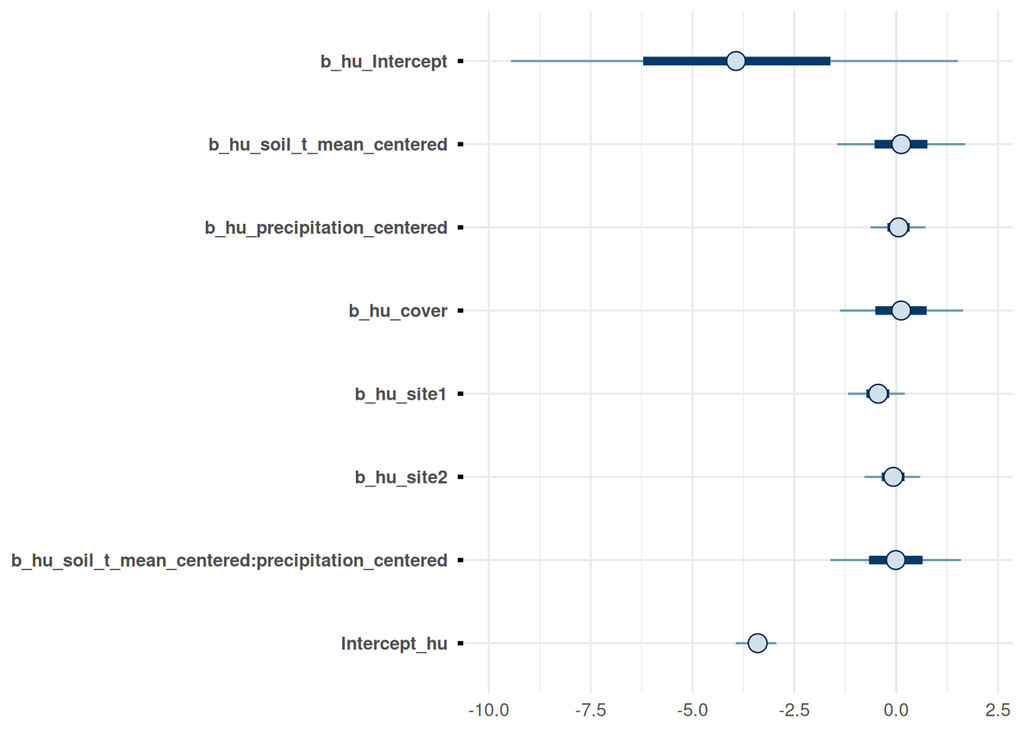

```r
mcmc_intervals(fit_spread_itp, pars = vars(contains("hu")))
```